# Análisis Estadístico Exhaustivo y Reporte de Resultados: Teclado Matemático Virtual vs. Pizarra Digital Manuscrita en Mateo Tutor

**Investigación de Tesis de Grado / Postgrado**  
**Autor del Estudio:** Nicolás Donoso  
**Plataforma Evaluada:** Tutor Inteligente de Matemáticas **Mateo Tutor** (Universidad Austral de Chile)  
**Módulo de Experimentación:** `src/pages/pruebaEstudiantes.tsx`  
**Datasets Analizados:**

1. `data_estudio_nicolasdonoso.xlsx` ($N = 14$ estudiantes, $84$ ensayos experimentales de telemetría y subescalas independientes NASA-TLX).
2. `Encuesta_ Uso de Tablets en Matemáticas (Respuestas).xlsx` ($N = 14$ estudiantes, Perfil Inicial y Experiencia Previa).
3. `Encuesta Final_ Evaluación del Sistema de Ecuaciones (Respuestas).xlsx` ($N = 14$ estudiantes, Evaluación Cualitativa y Preferencia Final).

### Índice General del Documento

1. **1. Introducción, Justificación Teórica e Hipótesis de Investigación**
   - 1.1 Contexto y Problema de Interacción Humano-Computador (HCI)
   - 1.2 Hipótesis Experimentales Formales ($H_1, H_2, H_3$)
   - 1.3 Definición de Variables y Niveles de Complejidad
2. **2. Metodología Experimental, Control de Sesgos y Caracterización de la Muestra**
   - 2.1 Inicialización del Entorno Científico y Estilos Visuales
   - 2.2 Ingesta de Datos y Control de Balanceo Experimental (Tablas 2.1 y 2.2)
   - 2.3 Perfil Académico y Experiencia Previa con Tablets (Tablas 2.3 y 2.4 - Pre-Encuesta)
   - 2.4 Cruce entre Experiencia Previa y Rendimiento Real (Tabla 2.5)
   - 2.5 Análisis Metodológico de la Muestra y Control de Sesgos
3. **3. Estadísticas Descriptivas Comparativas**
   - 3.1 Descriptivas Globales Lado a Lado (Tabla 3.1)
   - 3.2 Descriptivas por Nivel de Complejidad (Tabla 3.2)
4. **4. Inferencia Estadística, Contrastes Pareados, ANOVA $2 \times 3$, Correlaciones, Potencia y Matrices**
   - 4.1 Protocolo Metodológico y Regla de Decisión (Normalidad Shapiro-Wilk)
   - 4.2 Contrastes de Hipótesis Pareados Globales (Tabla 4.1)
   - 4.3 Contrastes de Hipótesis Pareados por Complejidad (Tabla 4.2)
   - 4.4 ANOVA de Dos Vías de Medidas Repetidas ($2 \times 3$), Esfericidad y Efectos Simples (Tablas 4.3 y 4.4)
     - 4.4.1 Formulación Matemática del Modelo y Fuentes de Variación
     - 4.4.2 Diagnóstico de Esfericidad y Corrección Greenhouse-Geisser
     - 4.4.3 Tabla Formal de Resultados del ANOVA $2 \times 3$ (Tabla 4.3)
     - 4.4.4 Descomposición de la Interacción: Efectos Simples con Corrección Bonferroni (Tabla 4.4)
     - 4.4.5 Reporte Formal y Síntesis Académica en Estándar APA 7ma Edición / IEEE
   - 4.5 Matriz de Correlaciones Bivariadas Inter-Variable (Tabla 4.5)
   - 4.6 Análisis de Potencia Estadística Post-Hoc ($1 - \beta$) y Sensibilidad Muestral (Tabla 4.6)
   - 4.7 Matrices de Cálculo Paso a Paso Usuario por Usuario ($N=14$) (Tablas 4.7.1 a 4.7.4)
5. **5. Visualizaciones y Análisis Gráfico Comparativo**
   - 5.1 Distribución y Dispersión: Boxplots con Stripplots en Grilla $2 \times 2$ (Gráfico 5.1)
   - 5.2 Trayectorias Individuales Intra-Sujeto: Spaghetti Plots en Grilla $2 \times 2$ (Gráfico 5.2)
   - 5.3 Perfil Multidimensional NASA-TLX: Radar Chart (Gráfico 5.3)
   - 5.4 Efecto de Interacción Modalidad × Complejidad: Interaction Plots en Grilla $2 \times 2$ (Gráfico 5.4)
   - 5.5 Desglose por Ejercicio Individual ($E1$ a $E6$) (Gráfico 5.5)
   - 5.6 Mapas de Calor de Correlación Inter-Variable (Gráfico 5.6)
6. **6. Evaluación Cualitativa Post-Estudio, Discusión Teórica y Conclusiones**
   - 6.1 Distribución de Preferencias Subjetivas (Tabla 6.1 y Gráfico 6.1)
   - 6.2 Matriz Cualitativa de Respuestas y Justificaciones de los Estudiantes (Tabla 6.2)
   - 6.3 Triangulación Metodológica e Interpretación con la Teoría de Carga Cognitiva (Sweller)
   - 6.4 Cuadro de Mando Ejecutivo y Síntesis Final de la Tesis (Tabla 6.3)
   - 6.5 Recomendaciones de Diseño de Interfaz y Arquitectura Adaptativa
   - 6.6 Conclusión Final de la Tesis

## 1. Introducción, Justificación Teórica e Hipótesis de Investigación

### 1.1 Contexto y Problema de Interacción Humano-Computador (HCI)

En la educación matemática digital existe una dificultad recurrente llamada **brecha de entrada**: a diferencia del texto común, las matemáticas combinan operaciones horizontales y verticales (como fracciones con numerador y denominador, exponentes y raíces cuadradas).

Los sistemas tradicionales suelen ofrecer dos alternativas:

1. **Sintaxis en texto (LaTeX / ASCII):** Obliga a memorizar comandos como `\frac{a}{b}` o `\sqrt{x}`.
2. **Teclados Matemáticos Virtuales (MathQuill / Botoneras):** Muestran los símbolos en pantalla, pero obligan al estudiante a buscar botones en paneles y mover el cursor entre cajas y niveles usando flechas o toques de pantalla.

Para solucionar esto en **Mateo Tutor**, se implementó una **Pizarra Digital Manuscrita con OCR** (`MathPixBoard`). En ella, el estudiante escribe directamente a mano alzada (con lápiz o dedo) y una red neuronal reconoce los trazos, convirtiéndolos automáticamente a formato matemático en tiempo real.

### 1.2 Hipótesis Experimentales Formales

- **Hipótesis de Eficiencia ($H_1$):** La Pizarra Manuscrita reduce significativamente el tiempo de ingreso (en segundos) en expresiones con fracciones y raíces en comparación con el Teclado Virtual.
- **Hipótesis de Carga Cognitiva ($H_2$):** La Pizarra Manuscrita reduce la demanda mental, el esfuerzo percibido y la frustración (evaluadas de forma independiente mediante las subescalas del NASA-TLX) al evitar la navegación manual del cursor.
- **Hipótesis de Interacción Modalidad $\times$ Complejidad ($H_3$):** Existe un efecto de cruce: el teclado virtual es eficiente en expresiones lineales simples (en una sola línea), mientras que la pizarra manuscrita resulta significativamente superior en expresiones con fracciones y raíces.

### 1.3 Definición de Variables y Niveles de Complejidad

- **Variables Independientes:**
  - **Modalidad de Entrada (2 condiciones intra-sujeto):** `teclado` (Teclado Virtual MathQuill) vs. `pizarra` (Pizarra Digital Manuscrita con OCR).
  - **Nivel de Complejidad Matemática (3 niveles intra-sujeto):**
    - **Baja ($E1, E2$ — Expresiones Lineales Simples):** Expresiones polinómicas en una sola línea, sin fracciones ni raíces (`(3x - 2)(x + 4)`, `(2x + 3)(x - 5)`).
    - **Media ($E3, E4$ — Fracciones Algebraicas):** Fracciones con potencias en numerador y denominador ($\frac{x^2 - 4}{x - 2}$, $\frac{x - 3}{x^2 - 9}$).
    - **Alta ($E5, E6$ — Ecuaciones con Raíces y Fracciones):** Ecuaciones con radicales dentro o fuera de fracciones ($\frac{2x - 1}{\sqrt{x^2 + 16}} = 3$, $\frac{\sqrt{x^2 + 16}}{2x - 1} = 3$).
- **Variables Dependientes (Subescalas Evaluadas de Forma Independiente):**
  - **Tiempo de Ejecución (`seconds`):** Segundos cronometrados desde que el usuario inicia el ejercicio hasta que envía su respuesta.
  - **Demanda Mental (`mentalDemand`):** Esfuerzo intelectual y de cálculo percibido según la escala NASA-TLX (0 a 100).
  - **Esfuerzo Percibido (`effort`):** Nivel de trabajo físico/operativo que el estudiante sintió invertir para ingresar la expresión (0 a 100).
  - **Nivel de Frustración (`frustration`):** Nivel de estrés, molestia o incomodidad durante la tarea (0 a 100).

## 2. Metodología Experimental, Control de Sesgos y Caracterización de la Muestra

### 2.1 Inicialización del Entorno Científico y Estilos Visuales

A continuación se cargan las librerías científicas requeridas y se configura el sistema de estilos cromáticos:

- **Pizarra Manuscrita:** Tono Azul Suave (`#ebf5fc` para fondos de celda, `#0b3c60` para texto/gráficos).
- **Teclado Virtual:** Tono Naranja Suave (`#fff4eb` para fondos de celda, `#8a3800` para texto/gráficos).
- **Contrastes y Deltas:** Gris Neutro Suave (`#f7f9fa`).

```python
import pandas as pd
import numpy as np
import scipy.stats as stats
import matplotlib.pyplot as plt
import seaborn as sns
import warnings

warnings.filterwarnings('ignore')
pd.set_option('display.max_columns', None)
pd.set_option('display.max_rows', None)
pd.set_option('display.width', 1000)

# Paleta y estilo institucional para gráficos
sns.set_theme(style="whitegrid", font_scale=1.05)
plt.rcParams['font.family'] = 'DejaVu Sans'
plt.rcParams['figure.autolayout'] = True

COLOR_PIZARRA = "#1f77b4"      # Azul
COLOR_TECLADO = "#ff7f0e"      # Naranja
COLOR_DELTA = "#555555"        # Gris
PALETTE_COND = {'pizarra': COLOR_PIZARRA, 'teclado': COLOR_TECLADO}
PALETTE_LABELS = {'Pizarra Manuscrita (OCR)': COLOR_PIZARRA, 'Teclado Virtual': COLOR_TECLADO}

# Estilos CSS reutilizables para tablas académicas sin emojis
CSS_TABLA_ACADEMICA = [
    {'selector': 'table', 'props': [('border-collapse', 'collapse'), ('width', '100%'), ('font-family', 'sans-serif'), ('font-size', '13px'), ('margin-bottom', '20px')]},
    {'selector': 'th', 'props': [('background-color', '#2c3e50'), ('color', '#ffffff'), ('font-weight', 'bold'), ('text-align', 'center'), ('padding', '8px 12px'), ('border', '1px solid #ddd')]},
    {'selector': 'td', 'props': [('padding', '7px 10px'), ('border', '1px solid #e0e0e0')]},
    {'selector': 'caption', 'props': [('caption-side', 'top'), ('font-size', '14px'), ('font-weight', 'bold'), ('color', '#2c3e50'), ('margin-bottom', '8px'), ('text-align', 'left')]}
]
```

### 2.2 Ingesta de Datos y Control de Balanceo Experimental

Se cargan los registros del archivo `data_estudio_nicolasdonoso.xlsx` ($N=14$, 84 registros). Se genera la matriz de asignación usuario por ejercicio y se verifica la simetría por complejidad.

```python
# 1. Carga del archivo Excel experimental
df = pd.read_excel('data_estudio_nicolasdonoso.xlsx')

# 2. Conversión a segundos
df['seconds'] = df['miliseconds'] / 1000.0

# 3. Mapeo de complejidad
complexity_map = {
    'ex-1': 'Baja',
    'ex-2': 'Baja',
    'ex-3': 'Media',
    'ex-4': 'Media',
    'ex-5': 'Alta',
    'ex-6': 'Alta'
}
df['complexity'] = df['exercise'].map(complexity_map)
df['complexity'] = pd.Categorical(df['complexity'], categories=['Baja', 'Media', 'Alta'], ordered=True)

# 4. Etiquetas descriptivas de condición
df['condicion_label'] = df['condicion'].map({'pizarra': 'Pizarra Manuscrita (OCR)', 'teclado': 'Teclado Virtual'})

# 5. Tabla 2.1: Matriz de Asignación Usuario x Ejercicio con Estilo por Condición
matriz_asignacion = pd.crosstab(df['user'], df['exercise'], values=df['condicion'], aggfunc='first')
matriz_asignacion.index.name = 'Participante'
matriz_asignacion.columns.name = 'Ejercicio'

def colorear_celda_modo(val):
    if val == 'pizarra':
        return 'background-color: #ebf5fc; color: #0b3c60; font-weight: bold; text-align: center;'
    elif val == 'teclado':
        return 'background-color: #fff4eb; color: #8a3800; font-weight: bold; text-align: center;'
    return 'text-align: center;'

styled_t21 = matriz_asignacion.style.applymap(colorear_celda_modo)
styled_t21 = styled_t21.set_table_styles(CSS_TABLA_ACADEMICA)
styled_t21 = styled_t21.set_caption("Tabla 2.1: Matriz de Asignación Experimental Intra-Sujeto (Azul: Pizarra | Naranja: Teclado)")
display(styled_t21)

# 6. Tabla 2.2: Verificación de Simetría por Complejidad y Condición
tabla_simetria = pd.crosstab(df['complexity'], df['condicion'], margins=True, margins_name="Total")
tabla_simetria.index.name = 'Complejidad'
tabla_simetria.columns.name = 'Modalidad'
styled_t22 = tabla_simetria.style.set_properties(**{'text-align': 'center', 'font-weight': 'bold'})
styled_t22 = styled_t22.set_table_styles(CSS_TABLA_ACADEMICA)
styled_t22 = styled_t22.set_caption("Tabla 2.2: Verificación de Balanceo Experimental (Ensayos por Celda)")
display(styled_t22)
```

Tabla 2.1: Matriz de Asignación Experimental Intra-Sujeto (Azul: Pizarra | Naranja: Teclado)

| Ejercicio Participante | ex-1 | ex-2 | ex-3 | ex-4 | ex-5 | ex-6 |
| --- | --- | --- | --- | --- | --- | --- |
| hw01 | pizarra | teclado | pizarra | teclado | pizarra | teclado |
| hw02 | teclado | pizarra | teclado | pizarra | teclado | pizarra |
| hw03 | pizarra | teclado | pizarra | teclado | pizarra | teclado |
| hw04 | teclado | pizarra | teclado | pizarra | teclado | pizarra |
| hw05 | pizarra | teclado | pizarra | teclado | pizarra | teclado |
| hw06 | teclado | pizarra | teclado | pizarra | teclado | pizarra |
| hw07 | pizarra | teclado | pizarra | teclado | pizarra | teclado |
| hw08 | teclado | pizarra | teclado | pizarra | teclado | pizarra |
| hw09 | pizarra | teclado | pizarra | teclado | pizarra | teclado |
| hw10 | teclado | pizarra | teclado | pizarra | teclado | pizarra |
| hw11 | pizarra | teclado | pizarra | teclado | pizarra | teclado |
| hw12 | teclado | pizarra | teclado | pizarra | teclado | pizarra |
| hw13 | pizarra | teclado | pizarra | teclado | pizarra | teclado |
| hw14 | teclado | pizarra | teclado | pizarra | teclado | pizarra |

Tabla 2.2: Verificación de Balanceo Experimental (Ensayos por Celda)

| Modalidad Complejidad | pizarra | teclado | Total |
| --- | --- | --- | --- |
| Baja | 14 | 14 | 28 |
| Media | 14 | 14 | 28 |
| Alta | 14 | 14 | 28 |
| Total | 42 | 42 | 84 |

### 2.3 Perfil Académico y Experiencia Previa con Tablets (Pre-Encuesta)

Antes de iniciar las pruebas, los 14 participantes completaron un cuestionario de caracterización demográfica, tecnológica y de hábitos de estudio (`Encuesta_ Uso de Tablets en Matemáticas (Respuestas).xlsx`).

```python
# Carga de la Pre-Encuesta
df_pre = pd.read_excel('Encuesta_ Uso de Tablets en Matemáticas (Respuestas).xlsx')
df_pre.columns = ['Timestamp', 'Participante', 'Ultimas Asignaturas Aprobadas', 'Familiaridad Previa con Tablets']
df_pre = df_pre.drop_duplicates(subset=['Participante']).copy()

# Tabla 2.3: Perfil Tecnológico y Experiencia Previa (3 Variables Principales)
n_total = len(df_pre)
n_con_exp = df_pre['Familiaridad Previa con Tablets'].str.contains('Sí|Si|frecuentemente', case=False, na=False).sum()
n_sin_exp = df_pre['Familiaridad Previa con Tablets'].str.contains('No', case=False, na=False).sum()

resumen_3var = {
    'Variable / Condición de Entrada': [
        'Total de participantes Evaluados (N)',
        'Con experiencia previa (frecuente o casual)',
        'Sin experiencia previa (principiante o nunca)'
    ],
    'Participantes (n)': [
        n_total,
        n_con_exp,
        n_sin_exp
    ],
    'Porcentaje (%)': [
        f"{(n_total / n_total)*100:.1f}%",
        f"{(n_con_exp / n_total)*100:.1f}%",
        f"{(n_sin_exp / n_total)*100:.1f}%"
    ],
    'Criterio de Inclusión y Subgrupos': [
        'Muestra completa de estudiantes universitarios evaluados (UACh)',
        'Usuarios con uso frecuente (n=3) o casual en pocas ocasiones (n=3)',
        'Usuarios que conocen el funcionamiento pero no escriben (n=4) o nunca han usado (n=4)'
    ]
}

df_tabla_23 = pd.DataFrame(resumen_3var)
df_tabla_23.set_index('Variable / Condición de Entrada', inplace=True)
styled_t23 = df_tabla_23.style.set_properties(subset=['Participantes (n)', 'Porcentaje (%)'], **{'text-align': 'center', 'font-weight': 'bold'})
styled_t23 = styled_t23.set_properties(subset=['Criterio de Inclusión y Subgrupos'], **{'text-align': 'left'})
styled_t23 = styled_t23.set_properties(subset=pd.IndexSlice[['Con experiencia previa (frecuente o casual)'], :], **{'background-color': '#ebf5fc'})
styled_t23 = styled_t23.set_properties(subset=pd.IndexSlice[['Sin experiencia previa (principiante o nunca)'], :], **{'background-color': '#fff4eb'})
styled_t23 = styled_t23.set_table_styles(CSS_TABLA_ACADEMICA)
styled_t23 = styled_t23.set_caption("Tabla 2.3: Perfil Tecnológico y Experiencia Previa con Tablets (Variables Consolidadas, N=14)")
display(styled_t23)

# Tabla 2.3b: Desglose Detallado por Nivel de Familiaridad Inicial
n_fam_frec = df_pre['Familiaridad Previa con Tablets'].str.contains('frecuentemente', case=False, na=False).sum()
n_fam_pocas = df_pre['Familiaridad Previa con Tablets'].str.contains('pocas ocasiones', case=False, na=False).sum()
n_fam_conoce = df_pre['Familiaridad Previa con Tablets'].str.contains('sé cómo funciona|se como funciona', case=False, na=False).sum()
n_fam_nunca = df_pre['Familiaridad Previa con Tablets'].str.contains('nunca', case=False, na=False).sum()

resumen_detallado = {
    'Categoría de Respuesta (Pre-Encuesta)': [
        'Familiaridad: Escribe frecuentemente en Tablet',
        'Familiaridad: Sí, pero en pocas ocasiones',
        'Familiaridad: No, pero conoce cómo funciona',
        'Familiaridad: No, nunca lo ha intentado'
    ],
    'Grupo Asignado': [
        'Con Experiencia Previa',
        'Con Experiencia Previa',
        'Sin Experiencia Previa',
        'Sin Experiencia Previa'
    ],
    'Frecuencia (n)': [n_fam_frec, n_fam_pocas, n_fam_conoce, n_fam_nunca],
    'Porcentaje (%)': [
        f"{(n_fam_frec / n_total)*100:.1f}%",
        f"{(n_fam_pocas / n_total)*100:.1f}%",
        f"{(n_fam_conoce / n_total)*100:.1f}%",
        f"{(n_fam_nunca / n_total)*100:.1f}%"
    ]
}

df_tabla_23b = pd.DataFrame(resumen_detallado)
df_tabla_23b.set_index('Categoría de Respuesta (Pre-Encuesta)', inplace=True)
styled_t23b = df_tabla_23b.style.set_properties(subset=['Grupo Asignado', 'Frecuencia (n)', 'Porcentaje (%)'], **{'text-align': 'center', 'font-weight': 'bold'})
styled_t23b = styled_t23b.set_properties(subset=pd.IndexSlice[['Familiaridad: Escribe frecuentemente en Tablet', 'Familiaridad: Sí, pero en pocas ocasiones'], :], **{'background-color': '#ebf5fc'})
styled_t23b = styled_t23b.set_properties(subset=pd.IndexSlice[['Familiaridad: No, pero conoce cómo funciona', 'Familiaridad: No, nunca lo ha intentado'], :], **{'background-color': '#fff4eb'})
styled_t23b = styled_t23b.set_table_styles(CSS_TABLA_ACADEMICA)
styled_t23b = styled_t23b.set_caption("Tabla 2.3b: Desglose Detallado por Nivel de Familiaridad Tecnológica Inicial (Pre-Encuesta, N=14)")
display(styled_t23b)

# Tabla 2.4: Matriz Individual de Pre-Encuesta
df_pre_indiv = df_pre[['Participante', 'Ultimas Asignaturas Aprobadas', 'Familiaridad Previa con Tablets']].copy()
df_pre_indiv.set_index('Participante', inplace=True)
styled_t24 = df_pre_indiv.style.set_properties(**{'text-align': 'left'})
styled_t24 = styled_t24.set_table_styles(CSS_TABLA_ACADEMICA)
styled_t24 = styled_t24.set_caption("Tabla 2.4: Caracterización Individual de Entrada por Participante (Pre-Encuesta, N=14)")
display(styled_t24)
```

Tabla 2.3: Perfil Tecnológico y Experiencia Previa con Tablets (Variables Consolidadas, N=14)

| Variable / Condición de Entrada | Participantes (n) | Porcentaje (%) | Criterio de Inclusión y Subgrupos |
| --- | --- | --- | --- |
| Total de participantes Evaluados (N) | 14 | 100.0% | Muestra completa de estudiantes universitarios evaluados (UACh) |
| Con experiencia previa (frecuente o casual) | 6 | 42.9% | Usuarios con uso frecuente (n=3) o casual en pocas ocasiones (n=3) |
| Sin experiencia previa (principiante o nunca) | 8 | 57.1% | Usuarios que conocen el funcionamiento pero no escriben (n=4) o nunca han usado (n=4) |

Tabla 2.3b: Desglose Detallado por Nivel de Familiaridad Tecnológica Inicial (Pre-Encuesta, N=14)

| Categoría de Respuesta (Pre-Encuesta) | Grupo Asignado | Frecuencia (n) | Porcentaje (%) |
| --- | --- | --- | --- |
| Familiaridad: Escribe frecuentemente en Tablet | Con Experiencia Previa | 3 | 21.4% |
| Familiaridad: Sí, pero en pocas ocasiones | Con Experiencia Previa | 3 | 21.4% |
| Familiaridad: No, pero conoce cómo funciona | Sin Experiencia Previa | 4 | 28.6% |
| Familiaridad: No, nunca lo ha intentado | Sin Experiencia Previa | 4 | 28.6% |

Tabla 2.4: Caracterización Individual de Entrada por Participante (Pre-Encuesta, N=14)

| Participante | Ultimas Asignaturas Aprobadas | Familiaridad Previa con Tablets |
| --- | --- | --- |
| hw03 | Álgebra | No, pero sé cómo funciona |
| hw07 | Algebra y geometria | No, pero sé cómo funciona |
| hw05 | Algebra y geometría | Sí, pero en pocas ocasiones |
| hw01 | Algebra y Geometria | Sí, pero en pocas ocasiones |
| hw08 | Algebra y geometría | No, pero sé cómo funciona |
| hw09 | Algebra y Geometria | No, nunca lo he intentado |
| hw06 | Álgebra y geometría | Sí, lo hago frecuentemente |
| hw10 | Algebra | No, nunca lo he intentado |
| hw02 | Álgebra e introducción al cálculo y geometría | Sí, lo hago frecuentemente |
| hw04 | Álgebra e introducción al cálculo y geometría | Sí, lo hago frecuentemente |
| hw14 | Álgebra y geometría | Sí, pero en pocas ocasiones |
| hw12 | Álgebra | No, nunca lo he intentado |
| hw11 | Geometría, inglés 1 | No, nunca lo he intentado |
| hw13 | Álgebra y Geometría | No, pero sé cómo funciona |

### 2.4 Cruce entre Experiencia Previa con Tablets y Rendimiento Real (Tabla 2.5)

Para determinar si la Pizarra Manuscrita presentó una barrera de entrada o curva de aprendizaje, se dividió la muestra en:

- **Grupo Sin Experiencia Previa / Principiantes ($n = 8$, $57.1\%$):** Estudiantes que nunca o casi nunca habían usado una tablet para matemáticas.
- **Grupo Con Experiencia Previa / Usuarios ($n = 6$, $42.9\%$):** Estudiantes familiarizados con el uso de pantallas táctiles o lápices.

Se evalúa a continuación el desempeño real en **Tiempo de Ejecución**, **Demanda Mental**, **Esfuerzo Percibido** y **Nivel de Frustración**.

```python
# Clasificar a los participantes según experiencia previa
def clasificar_exp(val):
    if 'No' in str(val):
        return 'Sin Experiencia Previa (n=8)'
    return 'Con Experiencia Previa (n=6)'

df_pre['Grupo_Experiencia'] = df_pre['Familiaridad Previa con Tablets'].apply(clasificar_exp)
df_merged = df.merge(df_pre[['Participante', 'Grupo_Experiencia']], left_on='user', right_on='Participante')

user_grp = df_merged.groupby(['user', 'Grupo_Experiencia', 'condicion'])[['seconds', 'mentalDemand', 'effort', 'frustration']].mean().unstack('condicion')

rows_t25 = []
metric_labels_t25 = {
    'seconds': 'Tiempo de Ejecución (s)',
    'mentalDemand': 'Demanda Mental (0-100)',
    'effort': 'Esfuerzo Percibido (0-100)',
    'frustration': 'Nivel de Frustración (0-100)'
}

for m in ['seconds', 'mentalDemand', 'effort', 'frustration']:
    for grp in ['Sin Experiencia Previa (n=8)', 'Con Experiencia Previa (n=6)']:
        sub_piz = user_grp[m]['pizarra'].loc[user_grp.index.get_level_values('Grupo_Experiencia') == grp]
        sub_tec = user_grp[m]['teclado'].loc[user_grp.index.get_level_values('Grupo_Experiencia') == grp]
        diff = sub_piz.mean() - sub_tec.mean()
        pct = (diff / sub_tec.mean()) * 100
        rows_t25.append({
            'Variable Evaluada': metric_labels_t25[m],
            'Grupo de Experiencia Previa': grp,
            'Pizarra Manuscrita': sub_piz.mean(),
            'Teclado Virtual': sub_tec.mean(),
            'Dif. Media (P - T)': diff,
            'Cambio Relativo %': pct
        })

df_t25 = pd.DataFrame(rows_t25)
df_t25.set_index(['Variable Evaluada', 'Grupo de Experiencia Previa'], inplace=True)

styled_t25 = df_t25.style.format({
    'Pizarra Manuscrita': '{:.2f}',
    'Teclado Virtual': '{:.2f}',
    'Dif. Media (P - T)': '{:+.2f}',
    'Cambio Relativo %': '{:+.1f}%'
})

styled_t25 = styled_t25.set_properties(subset=['Pizarra Manuscrita'], **{'background-color': '#ebf5fc', 'color': '#0b3c60', 'font-weight': 'bold', 'text-align': 'center'})
styled_t25 = styled_t25.set_properties(subset=['Teclado Virtual'], **{'background-color': '#fff4eb', 'color': '#8a3800', 'font-weight': 'bold', 'text-align': 'center'})
styled_t25 = styled_t25.set_properties(subset=['Dif. Media (P - T)'], **{'background-color': '#f7f9fa', 'color': '#111111', 'font-weight': 'bold', 'text-align': 'center'})
styled_t25 = styled_t25.set_properties(subset=['Cambio Relativo %'], **{'text-align': 'center'})
styled_t25 = styled_t25.set_table_styles(CSS_TABLA_ACADEMICA)
styled_t25 = styled_t25.set_caption("Tabla 2.5: Rendimiento Real Comparativo según Nivel de Experiencia Previa con Tablets (N=14)")
display(styled_t25)
```

Tabla 2.5: Rendimiento Real Comparativo según Nivel de Experiencia Previa con Tablets (N=14)

| Variable Evaluada | Grupo de Experiencia Previa | Pizarra Manuscrita | Teclado Virtual | Dif. Media (P - T) | Cambio Relativo % |
| --- | --- | --- | --- | --- | --- |
| Tiempo de Ejecución (s) | Sin Experiencia Previa (n=8) | 28.74 | 42.39 | -13.65 | -32.2% |
|  | Con Experiencia Previa (n=6) | 40.78 | 51.67 | -10.90 | -21.1% |
| Demanda Mental (0-100) | Sin Experiencia Previa (n=8) | 26.04 | 32.92 | -6.88 | -20.9% |
|  | Con Experiencia Previa (n=6) | 30.28 | 45.00 | -14.72 | -32.7% |
| Esfuerzo Percibido (0-100) | Sin Experiencia Previa (n=8) | 34.38 | 36.46 | -2.08 | -5.7% |
|  | Con Experiencia Previa (n=6) | 44.72 | 47.22 | -2.50 | -5.3% |
| Nivel de Frustración (0-100) | Sin Experiencia Previa (n=8) | 25.62 | 26.25 | -0.62 | -2.4% |
|  | Con Experiencia Previa (n=6) | 35.28 | 37.50 | -2.22 | -5.9% |

## 3. Estadísticas Descriptivas Comparativas

En esta sección se presentan las tablas comparativas lado a lado para cada una de las variables dependientes: **Pizarra Manuscrita (Azul)** frente a **Teclado Virtual (Naranja)**, incluyendo la **Diferencia Media** y el **Cambio Porcentual**:

- **Medidas Paramétricas:** Media ($\mu$) y Desviación Estándar ($\sigma$).
- **Medidas Robustas:** Mediana y Rango Intercuartílico ($IQR = Q_{75} - Q_{25}$).

### 3.1 Estadísticas Descriptivas Globales Comparativas (Tabla 3.1)

```python
metrics = ['seconds', 'mentalDemand', 'effort', 'frustration']
metric_names = {
    'seconds': 'Tiempo de Ejecución (s)',
    'mentalDemand': 'Demanda Mental (0-100)',
    'effort': 'Esfuerzo Percibido (0-100)',
    'frustration': 'Nivel de Frustración (0-100)'
}

# 1. Tabla 3.1: Descriptivas Globales Comparativas Lado a Lado
rows_t31 = []
for m in metrics:
    piz = df[df['condicion'] == 'pizarra'][m]
    tec = df[df['condicion'] == 'teclado'][m]
    diff = piz.mean() - tec.mean()
    pct = (diff / tec.mean()) * 100
    rows_t31.append({
        'Variable Evaluada': metric_names[m],
        ('Pizarra Manuscrita', 'Media'): piz.mean(),
        ('Pizarra Manuscrita', 'Desv. Est.'): piz.std(),
        ('Pizarra Manuscrita', 'Mediana'): piz.median(),
        ('Pizarra Manuscrita', 'IQR'): piz.quantile(0.75) - piz.quantile(0.25),
        ('Teclado Virtual', 'Media'): tec.mean(),
        ('Teclado Virtual', 'Desv. Est.'): tec.std(),
        ('Teclado Virtual', 'Mediana'): tec.median(),
        ('Teclado Virtual', 'IQR'): tec.quantile(0.75) - tec.quantile(0.25),
        ('Comparativa Directa', 'Dif. Media (P - T)'): diff,
        ('Comparativa Directa', 'Cambio Relativo %'): pct
    })

df_desc_global_comp = pd.DataFrame(rows_t31)
cols_t31 = pd.MultiIndex.from_tuples([
    ('Pizarra Manuscrita', 'Media'),
    ('Pizarra Manuscrita', 'Desv. Est.'),
    ('Pizarra Manuscrita', 'Mediana'),
    ('Pizarra Manuscrita', 'IQR'),
    ('Teclado Virtual', 'Media'),
    ('Teclado Virtual', 'Desv. Est.'),
    ('Teclado Virtual', 'Mediana'),
    ('Teclado Virtual', 'IQR'),
    ('Comparativa Directa', 'Dif. Media (P - T)'),
    ('Comparativa Directa', 'Cambio Relativo %')
])
df_desc_global_comp.set_index('Variable Evaluada', inplace=True)
df_desc_global_comp.columns = cols_t31

piz_cols_t31 = [c for c in cols_t31 if c[0] == 'Pizarra Manuscrita']
tec_cols_t31 = [c for c in cols_t31 if c[0] == 'Teclado Virtual']
comp_cols_t31 = [c for c in cols_t31 if c[0] == 'Comparativa Directa']

styled_t31 = df_desc_global_comp.style.format({
    ('Pizarra Manuscrita', 'Media'): '{:.2f}',
    ('Pizarra Manuscrita', 'Desv. Est.'): '{:.2f}',
    ('Pizarra Manuscrita', 'Mediana'): '{:.2f}',
    ('Pizarra Manuscrita', 'IQR'): '{:.2f}',
    ('Teclado Virtual', 'Media'): '{:.2f}',
    ('Teclado Virtual', 'Desv. Est.'): '{:.2f}',
    ('Teclado Virtual', 'Mediana'): '{:.2f}',
    ('Teclado Virtual', 'IQR'): '{:.2f}',
    ('Comparativa Directa', 'Dif. Media (P - T)'): '{:+.2f}',
    ('Comparativa Directa', 'Cambio Relativo %'): '{:+.1f}%'
})

styled_t31 = styled_t31.set_properties(subset=piz_cols_t31, **{'background-color': '#ebf5fc', 'color': '#0b3c60', 'text-align': 'center'})
styled_t31 = styled_t31.set_properties(subset=tec_cols_t31, **{'background-color': '#fff4eb', 'color': '#8a3800', 'text-align': 'center'})
styled_t31 = styled_t31.set_properties(subset=comp_cols_t31, **{'background-color': '#f7f9fa', 'color': '#111111', 'font-weight': 'bold', 'text-align': 'center'})
styled_t31 = styled_t31.set_table_styles(CSS_TABLA_ACADEMICA)
styled_t31 = styled_t31.set_caption("Tabla 3.1: Comparativa Descriptiva Global (Azul: Pizarra Manuscrita | Naranja: Teclado Virtual, N=42 por condición)")

display(styled_t31)
```

Tabla 3.1: Comparativa Descriptiva Global (Azul: Pizarra Manuscrita | Naranja: Teclado Virtual, N=42 por condición)

| Variable Evaluada | Pizarra Manuscrita Media | Pizarra Manuscrita Desv. Est. | Pizarra Manuscrita Mediana | Pizarra Manuscrita IQR | Teclado Virtual Media | Teclado Virtual Desv. Est. | Teclado Virtual Mediana | Teclado Virtual IQR | Comparativa Directa Dif. Media (P - T) | Comparativa Directa Cambio Relativo % |
| --- | --- | --- | --- | --- | --- | --- | --- | --- | --- | --- |
| Tiempo de Ejecución (s) | 33.90 | 26.67 | 24.91 | 25.00 | 46.37 | 37.94 | 34.82 | 33.90 | -12.47 | -26.9% |
| Demanda Mental (0-100) | 27.86 | 20.69 | 25.00 | 26.25 | 38.10 | 24.59 | 35.00 | 43.75 | -10.24 | -26.9% |
| Esfuerzo Percibido (0-100) | 38.81 | 21.80 | 30.00 | 25.00 | 41.07 | 23.52 | 40.00 | 35.00 | -2.26 | -5.5% |
| Nivel de Frustración (0-100) | 29.76 | 24.89 | 25.00 | 37.50 | 31.07 | 23.31 | 25.00 | 33.75 | -1.31 | -4.2% |

### 3.2 Estadísticas Descriptivas por Nivel de Complejidad (Tabla 3.2)

```python
# 2. Tabla 3.2: Descriptivas Desagregadas por Complejidad Comparativas Lado a Lado
rows_t32 = []
for comp in ['Baja', 'Media', 'Alta']:
    for m in metrics:
        sub_piz = df[(df['complexity'] == comp) & (df['condicion'] == 'pizarra')][m]
        sub_tec = df[(df['complexity'] == comp) & (df['condicion'] == 'teclado')][m]
        diff = sub_piz.mean() - sub_tec.mean()
        pct = (diff / sub_tec.mean()) * 100
        rows_t32.append({
            'Complejidad': comp,
            'Variable Evaluada': metric_names[m],
            ('Pizarra Manuscrita', 'Media'): sub_piz.mean(),
            ('Pizarra Manuscrita', 'Desv. Est.'): sub_piz.std(),
            ('Pizarra Manuscrita', 'Mediana'): sub_piz.median(),
            ('Pizarra Manuscrita', 'IQR'): sub_piz.quantile(0.75) - sub_piz.quantile(0.25),
            ('Teclado Virtual', 'Media'): sub_tec.mean(),
            ('Teclado Virtual', 'Desv. Est.'): sub_tec.std(),
            ('Teclado Virtual', 'Mediana'): sub_tec.median(),
            ('Teclado Virtual', 'IQR'): sub_tec.quantile(0.75) - sub_tec.quantile(0.25),
            ('Comparativa Directa', 'Dif. Media (P - T)'): diff,
            ('Comparativa Directa', 'Cambio Relativo %'): pct
        })

df_desc_comp = pd.DataFrame(rows_t32)
df_desc_comp.set_index(['Complejidad', 'Variable Evaluada'], inplace=True)
df_desc_comp.columns = cols_t31

styled_t32 = df_desc_comp.style.format({
    ('Pizarra Manuscrita', 'Media'): '{:.2f}',
    ('Pizarra Manuscrita', 'Desv. Est.'): '{:.2f}',
    ('Pizarra Manuscrita', 'Mediana'): '{:.2f}',
    ('Pizarra Manuscrita', 'IQR'): '{:.2f}',
    ('Teclado Virtual', 'Media'): '{:.2f}',
    ('Teclado Virtual', 'Desv. Est.'): '{:.2f}',
    ('Teclado Virtual', 'Mediana'): '{:.2f}',
    ('Teclado Virtual', 'IQR'): '{:.2f}',
    ('Comparativa Directa', 'Dif. Media (P - T)'): '{:+.2f}',
    ('Comparativa Directa', 'Cambio Relativo %'): '{:+.1f}%'
})

styled_t32 = styled_t32.set_properties(subset=piz_cols_t31, **{'background-color': '#ebf5fc', 'color': '#0b3c60', 'text-align': 'center'})
styled_t32 = styled_t32.set_properties(subset=tec_cols_t31, **{'background-color': '#fff4eb', 'color': '#8a3800', 'text-align': 'center'})
styled_t32 = styled_t32.set_properties(subset=comp_cols_t31, **{'background-color': '#f7f9fa', 'color': '#111111', 'font-weight': 'bold', 'text-align': 'center'})
styled_t32 = styled_t32.set_table_styles(CSS_TABLA_ACADEMICA)
styled_t32 = styled_t32.set_caption("Tabla 3.2: Comparativa Descriptiva por Nivel de Complejidad Matemática")

display(styled_t32)
```

Tabla 3.2: Comparativa Descriptiva por Nivel de Complejidad Matemática

| Complejidad | Variable Evaluada | Pizarra Manuscrita Media | Pizarra Manuscrita Desv. Est. | Pizarra Manuscrita Mediana | Pizarra Manuscrita IQR | Teclado Virtual Media | Teclado Virtual Desv. Est. | Teclado Virtual Mediana | Teclado Virtual IQR | Comparativa Directa Dif. Media (P - T) | Comparativa Directa Cambio Relativo % |
| --- | --- | --- | --- | --- | --- | --- | --- | --- | --- | --- | --- |
| Baja | Tiempo de Ejecución (s) | 30.25 | 16.17 | 25.40 | 21.70 | 20.94 | 5.14 | 19.82 | 4.68 | +9.32 | +44.5% |
|  | Demanda Mental (0-100) | 21.43 | 17.70 | 22.50 | 25.00 | 23.93 | 15.09 | 22.50 | 18.75 | -2.50 | -10.4% |
|  | Esfuerzo Percibido (0-100) | 38.21 | 21.00 | 32.50 | 25.00 | 28.93 | 17.56 | 30.00 | 22.50 | +9.29 | +32.1% |
|  | Nivel de Frustración (0-100) | 36.43 | 26.56 | 37.50 | 37.50 | 22.86 | 18.58 | 20.00 | 22.50 | +13.57 | +59.4% |
| Media | Tiempo de Ejecución (s) | 32.09 | 35.34 | 19.32 | 11.99 | 63.03 | 52.39 | 46.88 | 39.73 | -30.94 | -49.1% |
|  | Demanda Mental (0-100) | 26.07 | 20.86 | 22.50 | 17.50 | 42.86 | 25.77 | 45.00 | 42.50 | -16.79 | -39.2% |
|  | Esfuerzo Percibido (0-100) | 33.21 | 20.81 | 25.00 | 26.25 | 47.86 | 25.02 | 50.00 | 36.25 | -14.64 | -30.6% |
|  | Nivel de Frustración (0-100) | 22.14 | 23.75 | 15.00 | 22.50 | 37.14 | 29.20 | 32.50 | 32.50 | -15.00 | -40.4% |
| Alta | Tiempo de Ejecución (s) | 39.36 | 26.12 | 34.02 | 34.38 | 55.14 | 26.27 | 49.41 | 15.28 | -15.78 | -28.6% |
|  | Demanda Mental (0-100) | 36.07 | 21.94 | 30.00 | 28.75 | 47.50 | 26.07 | 50.00 | 36.25 | -11.43 | -24.1% |
|  | Esfuerzo Percibido (0-100) | 45.00 | 23.45 | 45.00 | 28.75 | 46.43 | 23.89 | 50.00 | 28.75 | -1.43 | -3.1% |
|  | Nivel de Frustración (0-100) | 30.71 | 23.93 | 32.50 | 27.50 | 33.21 | 19.96 | 32.50 | 27.50 | -2.50 | -7.5% |

#### Análisis e Interpretación de la Tabla 3.2 (Por Complejidad)

1. **Complejidad Baja (Expresiones Lineales Simples):**
   - El **Teclado Virtual** demostró ser más ágil en tiempo ($20.94\text{ s}$ vs. $30.25\text{ s}$, $\Delta = +9.32\text{ s}$), debido a que escribir expresiones en una sola línea no requiere navegación bidimensional ni cambios de nivel.
2. **Complejidad Media (Fracciones Algebraicas):**
   - Se invierte la tendencia de forma contundente: la **Pizarra Manuscrita** redujo el tiempo de resolución a la mitad ($32.09\text{ s}$ vs. $63.03\text{ s}$, **$-49.1\%$ de ahorro de tiempo**, $p = 0.0245$).
   - En **Demanda Mental**, la Pizarra redujo el esfuerzo cognitivo de $42.86$ a $26.07$ (**$-39.2\%$**, $p = 0.0464$).
   - En **Esfuerzo Percibido**, la Pizarra redujo la fatiga de $47.86$ a $33.21$ (**$-30.6\%$**, $p = 0.0850$).
   - En **Nivel de Frustración**, la Pizarra redujo la fricción de $37.14$ a $22.14$ (**$-40.4\%$**, $p = 0.0289$).
3. **Complejidad Alta (Ecuaciones con Raíces y Fracciones):**
   - La Pizarra mantuvo ventaja en tiempo ($39.36\text{ s}$ vs. $55.14\text{ s}$, **$-28.6\%$**) y menor demanda mental ($36.07$ vs. $47.50$, **$-24.1\%$**), preservando la estabilidad cognitiva ante expresiones no lineales.

## 4. Inferencia Estadística, Contrastes Pareados, ANOVA $2 \times 3$, Correlaciones, Potencia y Matrices

### 4.1 Protocolo Metodológico y Regla de Decisión

- **Diseño:** Intra-sujeto (*Within-Subjects* / Medidas Repetidas, $N = 14$). Cada participante actúa como su propio control.
- **Test de Normalidad:** Shapiro-Wilk sobre el vector de diferencias pareadas ($\Delta_i = x_{i,\text{pizarra}} - x_{i,\text{teclado}}$).
  - Si $p_{\text{Shapiro}} \ge 0.05$: Se aplica **t-Student Pareado** (*Paired Samples t-test*) y se reporta el tamaño del efecto con **d de Cohen intra-sujeto** ($d = \frac{\bar{\Delta}}{s_{\Delta}}$).
  - Si $p_{\text{Shapiro}} < 0.05$: Se aplica el test no paramétrico de **Rangos con Signo de Wilcoxon** (*Wilcoxon Signed-Rank Test*) y se reporta el tamaño del efecto con el coeficiente de correlación de rangos ($r = \frac{Z}{\sqrt{N}}$ o $d$ equivalente).

```python
# Estructura de agregación a nivel de usuario para contrastes pareados
user_summary = df.groupby(['user', 'condicion'])[metrics].mean().unstack('condicion')

def contrastar_pares(vec_pizarra, vec_teclado, nombre_var):
    diff = vec_pizarra - vec_teclado
    n = len(diff)
    mean_diff = diff.mean()
    std_diff = diff.std(ddof=1)

    # 1. Test de Normalidad Shapiro-Wilk sobre las diferencias
    stat_sw, p_sw = stats.shapiro(diff)
    es_normal = p_sw >= 0.05

    if es_normal:
        # T-Student Pareado
        t_stat, p_val = stats.ttest_rel(vec_pizarra, vec_teclado)
        test_name = "t-Student Pareado"
        stat_val = t_stat
        df_deg = n - 1
        d_cohen = mean_diff / std_diff if std_diff > 0 else 0.0
        effect_size = d_cohen
        effect_name = "d de Cohen"
        # IC 95%
        se = std_diff / np.sqrt(n)
        ci_low = mean_diff - stats.t.ppf(0.975, df_deg) * se
        ci_high = mean_diff + stats.t.ppf(0.975, df_deg) * se
    else:
        # Wilcoxon
        w_stat, p_val = stats.wilcoxon(vec_pizarra, vec_teclado)
        test_name = "Wilcoxon Pareado"
        stat_val = w_stat
        df_deg = np.nan
        # Aprox r de Wilcoxon
        z_approx = stats.norm.ppf(1.0 - p_val/2.0) if p_val < 1.0 else 0.0
        r_effect = -np.sign(mean_diff) * (z_approx / np.sqrt(n * 2))
        effect_size = r_effect
        effect_name = "r de Wilcoxon"
        ci_low = np.percentile(diff, 2.5)
        ci_high = np.percentile(diff, 97.5)

    sig = "Significativo (p < 0.05)" if p_val < 0.05 else ("Tendencia (p < 0.10)" if p_val < 0.10 else "No significativo")

    return {
        'Variable': nombre_var,
        'N': n,
        'Dif. Media (P - T)': mean_diff,
        'DE Dif.': std_diff,
        'IC 95% Inf': ci_low,
        'IC 95% Sup': ci_high,
        'Shapiro-Wilk W': stat_sw,
        'Shapiro p-val': p_sw,
        'Normalidad': 'Sí (p>=0.05)' if es_normal else 'No (p<0.05)',
        'Prueba Aplicada': test_name,
        'Estadístico': stat_val,
        'gl': df_deg,
        'p-valor': p_val,
        'Tamaño del Efecto': effect_size,
        'Métrica Efecto': effect_name,
        'Significancia': sig
    }
```

### 4.2 Contrastes de Hipótesis Pareados Globales ($N=14$) (Tabla 4.1)

```python
# 1. Tabla 4.1: Contrastes Globales
rows_t41 = []
for m in metrics:
    res = contrastar_pares(user_summary[m]['pizarra'], user_summary[m]['teclado'], metric_names[m])
    rows_t41.append(res)

df_t41 = pd.DataFrame(rows_t41)
df_t41.set_index('Variable', inplace=True)

styled_t41 = df_t41.style.format({
    'Dif. Media (P - T)': '{:+.2f}',
    'DE Dif.': '{:.2f}',
    'IC 95% Inf': '{:+.2f}',
    'IC 95% Sup': '{:+.2f}',
    'Shapiro-Wilk W': '{:.3f}',
    'Shapiro p-val': '{:.4f}',
    'Estadístico': '{:.3f}',
    'p-valor': '{:.4f}',
    'Tamaño del Efecto': '{:+.3f}'
})

styled_t41 = styled_t41.set_properties(subset=['p-valor', 'Significancia', 'Prueba Aplicada'], **{'font-weight': 'bold', 'text-align': 'center'})
styled_t41 = styled_t41.set_table_styles(CSS_TABLA_ACADEMICA)
styled_t41 = styled_t41.set_caption("Tabla 4.1: Contrastes de Inferencia Estadística Pareada Global (N=14 Estudiantes)")
display(styled_t41)
```

Tabla 4.1: Contrastes de Inferencia Estadística Pareada Global (N=14 Estudiantes)

| Variable | N | Dif. Media (P - T) | DE Dif. | IC 95% Inf | IC 95% Sup | Shapiro-Wilk W | Shapiro p-val | Normalidad | Prueba Aplicada | Estadístico | gl | p-valor | Tamaño del Efecto | Métrica Efecto | Significancia |
| --- | --- | --- | --- | --- | --- | --- | --- | --- | --- | --- | --- | --- | --- | --- | --- |
| Tiempo de Ejecución (s) | 14 | -12.47 | 24.10 | -26.38 | +1.44 | 0.960 | 0.7241 | Sí (p>=0.05) | t-Student Pareado | -1.936 | 13 | 0.0749 | -0.517 | d de Cohen | Tendencia (p < 0.10) |
| Demanda Mental (0-100) | 14 | -10.24 | 15.67 | -19.29 | -1.19 | 0.957 | 0.6692 | Sí (p>=0.05) | t-Student Pareado | -2.444 | 13 | 0.0295 | -0.653 | d de Cohen | Significativo (p < 0.05) |
| Esfuerzo Percibido (0-100) | 14 | -2.26 | 16.69 | -11.90 | +7.37 | 0.916 | 0.1904 | Sí (p>=0.05) | t-Student Pareado | -0.507 | 13 | 0.6205 | -0.136 | d de Cohen | No significativo |
| Nivel de Frustración (0-100) | 14 | -1.31 | 10.73 | -7.50 | +4.88 | 0.936 | 0.3725 | Sí (p>=0.05) | t-Student Pareado | -0.457 | 13 | 0.6553 | -0.122 | d de Cohen | No significativo |

### 4.3 Contrastes de Hipótesis Pareados por Nivel de Complejidad (Tabla 4.2)

```python
# 2. Tabla 4.2: Contrastes por Nivel de Complejidad
rows_t42 = []
user_comp_summary = df.groupby(['user', 'complexity', 'condicion'])[metrics].mean().unstack('condicion')

for comp in ['Baja', 'Media', 'Alta']:
    for m in metrics:
        sub_piz = user_comp_summary[m]['pizarra'].loc[user_comp_summary.index.get_level_values('complexity') == comp]
        sub_tec = user_comp_summary[m]['teclado'].loc[user_comp_summary.index.get_level_values('complexity') == comp]
        res = contrastar_pares(sub_piz.values, sub_tec.values, metric_names[m])
        res['Complejidad'] = comp
        rows_t42.append(res)

df_t42 = pd.DataFrame(rows_t42)
df_t42.set_index(['Complejidad', 'Variable'], inplace=True)

styled_t42 = df_t42.style.format({
    'Dif. Media (P - T)': '{:+.2f}',
    'DE Dif.': '{:.2f}',
    'IC 95% Inf': '{:+.2f}',
    'IC 95% Sup': '{:+.2f}',
    'Shapiro-Wilk W': '{:.3f}',
    'Shapiro p-val': '{:.4f}',
    'Estadístico': '{:.3f}',
    'p-valor': '{:.4f}',
    'Tamaño del Efecto': '{:+.3f}'
})

styled_t42 = styled_t42.set_properties(subset=['p-valor', 'Significancia', 'Prueba Aplicada'], **{'font-weight': 'bold', 'text-align': 'center'})
styled_t42 = styled_t42.set_table_styles(CSS_TABLA_ACADEMICA)
styled_t42 = styled_t42.set_caption("Tabla 4.2: Contrastes de Inferencia Estadística Pareada Desagregados por Complejidad (N=14)")
display(styled_t42)
```

Tabla 4.2: Contrastes de Inferencia Estadística Pareada Desagregados por Complejidad (N=14)

| Complejidad | Variable | N | Dif. Media (P - T) | DE Dif. | IC 95% Inf | IC 95% Sup | Shapiro-Wilk W | Shapiro p-val | Normalidad | Prueba Aplicada | Estadístico | gl | p-valor | Tamaño del Efecto | Métrica Efecto | Significancia |
| --- | --- | --- | --- | --- | --- | --- | --- | --- | --- | --- | --- | --- | --- | --- | --- | --- |
| Baja | Tiempo de Ejecución (s) | 14 | +9.32 | 16.22 | -0.05 | +18.68 | 0.901 | 0.1177 | Sí (p>=0.05) | t-Student Pareado | 2.149 | 13.000000 | 0.0510 | +0.574 | d de Cohen | Tendencia (p < 0.10) |
|  | Demanda Mental (0-100) | 14 | -2.50 | 12.97 | -9.99 | +4.99 | 0.954 | 0.6198 | Sí (p>=0.05) | t-Student Pareado | -0.721 | 13.000000 | 0.4836 | -0.193 | d de Cohen | No significativo |
|  | Esfuerzo Percibido (0-100) | 14 | +9.29 | 23.19 | -4.11 | +22.68 | 0.901 | 0.1156 | Sí (p>=0.05) | t-Student Pareado | 1.498 | 13.000000 | 0.1580 | +0.400 | d de Cohen | No significativo |
|  | Nivel de Frustración (0-100) | 14 | +13.57 | 23.49 | -11.75 | +63.37 | 0.827 | 0.0111 | No (p<0.05) | Wilcoxon Pareado | 5.000 | nan | 0.0376 | -0.393 | r de Wilcoxon | Significativo (p < 0.05) |
| Media | Tiempo de Ejecución (s) | 14 | -30.94 | 67.70 | -162.13 | +84.17 | 0.855 | 0.0260 | No (p<0.05) | Wilcoxon Pareado | 17.000 | nan | 0.0245 | +0.425 | r de Wilcoxon | Significativo (p < 0.05) |
|  | Demanda Mental (0-100) | 14 | -16.79 | 28.53 | -33.26 | -0.31 | 0.953 | 0.6069 | Sí (p>=0.05) | t-Student Pareado | -2.202 | 13.000000 | 0.0464 | -0.588 | d de Cohen | Significativo (p < 0.05) |
|  | Esfuerzo Percibido (0-100) | 14 | -14.64 | 29.38 | -31.61 | +2.32 | 0.905 | 0.1346 | Sí (p>=0.05) | t-Student Pareado | -1.865 | 13.000000 | 0.0850 | -0.498 | d de Cohen | Tendencia (p < 0.10) |
|  | Nivel de Frustración (0-100) | 14 | -15.00 | 23.86 | -65.25 | +8.37 | 0.856 | 0.0267 | No (p<0.05) | Wilcoxon Pareado | 8.500 | nan | 0.0289 | +0.413 | r de Wilcoxon | Significativo (p < 0.05) |
| Alta | Tiempo de Ejecución (s) | 14 | -15.78 | 31.67 | -34.07 | +2.50 | 0.948 | 0.5265 | Sí (p>=0.05) | t-Student Pareado | -1.865 | 13.000000 | 0.0849 | -0.498 | d de Cohen | Tendencia (p < 0.10) |
|  | Demanda Mental (0-100) | 14 | -11.43 | 25.68 | -26.25 | +3.40 | 0.909 | 0.1540 | Sí (p>=0.05) | t-Student Pareado | -1.665 | 13.000000 | 0.1197 | -0.445 | d de Cohen | No significativo |
|  | Esfuerzo Percibido (0-100) | 14 | -1.43 | 17.91 | -37.00 | +26.87 | 0.823 | 0.0098 | No (p<0.05) | Wilcoxon Pareado | 21.000 | nan | 0.8572 | +0.034 | r de Wilcoxon | No significativo |
|  | Nivel de Frustración (0-100) | 14 | -2.50 | 11.22 | -26.88 | +10.00 | 0.808 | 0.0063 | No (p<0.05) | Wilcoxon Pareado | 18.000 | nan | 0.5873 | +0.103 | r de Wilcoxon | No significativo |

### 4.4 ANOVA de Dos Vías de Medidas Repetidas ($2 \times 3$), Esfericidad y Efectos Simples (Tablas 4.3 y 4.4)

El **Two-Way Repeated Measures ANOVA** ($2 \text{ Modalidades} \times 3 \text{ Niveles de Complejidad}$, intra-sujeto $N = 14$) constituye la prueba inferencial más rigurosa para modelar simultáneamente los factores experimentales y formalizar matemáticamente la **Hipótesis $H_3$ (Efecto de Interacción)**.

#### 4.4.1 Formulación Matemática del Modelo y Fuentes de Variación

El modelo lineal general con dos factores intra-sujeto se define formalmente como:

$$Y_{ijk} = \mu + \pi_i + \alpha_j + \beta_k + (\alpha\beta)_{jk} + (\pi\alpha)_{ij} + (\pi\beta)_{ik} + \epsilon_{ijk}$$

Donde:

- $\mu$: Gran media poblacional global.
- $\pi_i$: Efecto aleatorio del sujeto $i$ ($i = 1, \dots, N=14$), con $\sum \pi_i = 0$.
- $\alpha_j$: Efecto fijo del **Factor A (Modalidad de Entrada)** con $a = 2$ niveles (`pizarra`, `teclado`), $gl_A = a - 1 = 1$.
- $\beta_k$: Efecto fijo del **Factor B (Complejidad Matemática)** con $b = 3$ niveles (`Baja`, `Media`, `Alta`), $gl_B = b - 1 = 2$.
- $(\alpha\beta)_{jk}$: Efecto de **Interacción Modalidad $\times$ Complejidad**, con $gl_{AB} = (a - 1)(b - 1) = 2$.
- $(\pi\alpha)_{ij}, (\pi\beta)_{ik}, \epsilon_{ijk}$: Términos de error intra-sujeto asociados a cada efecto:
  - Error de Modalidad: $gl_{AS} = (a - 1)(N - 1) = 1 \times 13 = 13$.
  - Error de Complejidad: $gl_{BS} = (b - 1)(N - 1) = 2 \times 13 = 26$.
  - Error de Interacción: $gl_{ABS} = (a - 1)(b - 1)(N - 1) = 2 \times 13 = 26$.

#### 4.4.2 Diagnóstico de Esfericidad y Corrección Greenhouse-Geisser ($\hat{\epsilon}$)

Para los efectos con más de dos niveles ($gl > 1$, es decir, Complejidad e Interacción), se calculó el índice de esfericidad de **Greenhouse-Geisser ($\hat{\epsilon}_{\text{GG}}$)**:

- Si $\hat{\epsilon} = 1.0$: Se cumple perfectamente el supuesto de esfericidad (igualdad de varianzas de las diferencias).
- Si $\hat{\epsilon} < 1.0$: Se ajustan los grados de libertad multiplicándolos por $\hat{\epsilon}$ ($gl_{\text{adj}} = \hat{\epsilon} \cdot gl$), recalculando el $p$-valor ajustado ($p_{\text{GG}}$) para prevenir falsos positivos tipo I.

```python
# Algoritmo Exhaustivo de Two-Way Repeated Measures ANOVA (2x3) con Corrección Greenhouse-Geisser
def calcular_gg_epsilon(data_matrix):
    N, k = data_matrix.shape
    if k <= 2:
        return 1.0
    S = np.cov(data_matrix, rowvar=False, ddof=1)
    mean_row_S = np.mean(S, axis=1)
    mean_S = np.mean(S)

    numerator = (k * (np.mean(np.diag(S)) - mean_S))**2
    denom_sum = 0.0
    for i in range(k):
        for j in range(k):
            term = S[i, j] - mean_row_S[i] - mean_row_S[j] + mean_S
            denom_sum += term**2
    denom = (k - 1) * denom_sum
    eps = numerator / denom if denom > 0 else 1.0
    return min(max(eps, 1.0 / (k - 1)), 1.0)

def calcular_rm_anova_completo_2x3(data, metric_col, label_name):
    users = sorted(data['user'].unique())
    conds = ['pizarra', 'teclado']
    comps = ['Baja', 'Media', 'Alta']
    N = len(users)
    a = len(conds)
    b = len(comps)

    piv = data.pivot(index='user', columns=['condicion', 'complexity'], values=metric_col)

    Y = np.zeros((N, a, b))
    for i, u in enumerate(users):
        for j, c in enumerate(conds):
            for k, cp in enumerate(comps):
                Y[i, j, k] = piv.loc[u, (c, cp)]

    grand_mean = Y.mean()
    mean_S = Y.mean(axis=(1, 2))
    mean_A = Y.mean(axis=(0, 2))
    mean_B = Y.mean(axis=(0, 1))
    mean_AB = Y.mean(axis=0)
    mean_AS = Y.mean(axis=2)
    mean_BS = Y.mean(axis=1)

    SS_A = N * b * np.sum((mean_A - grand_mean)**2)
    SS_B = N * a * np.sum((mean_B - grand_mean)**2)
    SS_AB = N * np.sum((mean_AB - mean_A[:, None] - mean_B[None, :] + grand_mean)**2)

    SS_AS = b * np.sum((mean_AS - mean_S[:, None] - mean_A[None, :] + grand_mean)**2)
    SS_BS = a * np.sum((mean_BS - mean_S[:, None] - mean_B[None, :] + grand_mean)**2)

    dev_ABS = np.zeros((N, a, b))
    for i in range(N):
        for j in range(a):
            for k in range(b):
                dev_ABS[i, j, k] = (Y[i, j, k] - mean_AS[i, j] - mean_BS[i, k] + mean_S[i] - mean_AB[j, k] + mean_A[j] + mean_B[k] - grand_mean)
    SS_ABS = np.sum(dev_ABS**2)

    df_A = a - 1
    df_AS = (a - 1) * (N - 1)
    df_B = b - 1
    df_BS = (b - 1) * (N - 1)
    df_AB = (a - 1) * (b - 1)
    df_ABS = (a - 1) * (b - 1) * (N - 1)

    MS_A = SS_A / df_A
    MS_AS = SS_AS / df_AS
    F_A = MS_A / MS_AS
    p_A = 1.0 - stats.f.cdf(F_A, df_A, df_AS)
    eta_p_A = SS_A / (SS_A + SS_AS)

    MS_B = SS_B / df_B
    MS_BS = SS_BS / df_BS
    F_B = MS_B / MS_BS
    p_B = 1.0 - stats.f.cdf(F_B, df_B, df_BS)
    eta_p_B = SS_B / (SS_B + SS_BS)

    MS_AB = SS_AB / df_AB
    MS_ABS = SS_ABS / df_ABS
    F_AB = MS_AB / MS_ABS
    p_AB = 1.0 - stats.f.cdf(F_AB, df_AB, df_ABS)
    eta_p_AB = SS_AB / (SS_AB + SS_ABS)

    eps_A = 1.0
    mat_B = mean_BS
    eps_B = calcular_gg_epsilon(mat_B)
    p_B_gg = 1.0 - stats.f.cdf(F_B, df_B * eps_B, df_BS * eps_B)

    diff_AB = Y[:, 0, :] - Y[:, 1, :]
    eps_AB = calcular_gg_epsilon(diff_AB)
    p_AB_gg = 1.0 - stats.f.cdf(F_AB, df_AB * eps_AB, df_ABS * eps_AB)

    rows = [
        {
            'Variable': label_name,
            'Fuente de Variación': 'Modalidad (A)',
            'SS': SS_A,
            'gl': f"{df_A}, {df_AS}",
            'MS': MS_A,
            'F': F_A,
            'p-valor': p_A,
            'ηp²': eta_p_A,
            'Epsilon GG': eps_A,
            'p-valor (GG)': p_A,
            'Significancia': 'Significativo (p < 0.05)' if p_A < 0.05 else ('Tendencia (p < 0.10)' if p_A < 0.10 else 'No signif.')
        },
        {
            'Variable': label_name,
            'Fuente de Variación': 'Complejidad (B)',
            'SS': SS_B,
            'gl': f"{df_B}, {df_BS}",
            'MS': MS_B,
            'F': F_B,
            'p-valor': p_B,
            'ηp²': eta_p_B,
            'Epsilon GG': eps_B,
            'p-valor (GG)': p_B_gg,
            'Significancia': 'Significativo (p < 0.05)' if p_B_gg < 0.05 else ('Tendencia (p < 0.10)' if p_B_gg < 0.10 else 'No signif.')
        },
        {
            'Variable': label_name,
            'Fuente de Variación': 'Interacción (A × B)',
            'SS': SS_AB,
            'gl': f"{df_AB}, {df_ABS}",
            'MS': MS_AB,
            'F': F_AB,
            'p-valor': p_AB,
            'ηp²': eta_p_AB,
            'Epsilon GG': eps_AB,
            'p-valor (GG)': p_AB_gg,
            'Significancia': 'Significativo (p < 0.05)' if p_AB_gg < 0.05 else ('Tendencia (p < 0.10)' if p_AB_gg < 0.10 else 'No signif.')
        }
    ]
    return rows

agg_data = df.groupby(['user', 'complexity', 'condicion'])[['seconds', 'mentalDemand', 'effort', 'frustration']].mean().reset_index()

anova_rows = []
for col, name in [('seconds', 'Tiempo de Ejecución (s)'),
                  ('mentalDemand', 'Demanda Mental (0-100)'),
                  ('effort', 'Esfuerzo Percibido (0-100)'),
                  ('frustration', 'Nivel de Frustración (0-100)')]:
    anova_rows.extend(calcular_rm_anova_completo_2x3(agg_data, col, name))

df_anova = pd.DataFrame(anova_rows)
df_anova.set_index(['Variable', 'Fuente de Variación'], inplace=True)

styled_t43 = df_anova.style.format({
    'SS': '{:.2f}',
    'MS': '{:.2f}',
    'F': '{:.3f}',
    'p-valor': '{:.4f}',
    'ηp²': '{:.3f}',
    'Epsilon GG': '{:.3f}',
    'p-valor (GG)': '{:.4f}'
})

styled_t43 = styled_t43.set_properties(subset=['gl', 'F', 'p-valor', 'ηp²', 'p-valor (GG)', 'Significancia'], **{'text-align': 'center', 'font-weight': 'bold'})
styled_t43 = styled_t43.set_properties(subset=['SS', 'MS', 'Epsilon GG'], **{'text-align': 'center'})
styled_t43 = styled_t43.set_table_styles(CSS_TABLA_ACADEMICA)
styled_t43 = styled_t43.set_caption("Tabla 4.3: ANOVA de Dos Vías de Medidas Repetidas (2x3) con Ajuste Greenhouse-Geisser (N=14)")
display(styled_t43)
```

Tabla 4.3: ANOVA de Dos Vías de Medidas Repetidas (2x3) con Ajuste Greenhouse-Geisser (N=14)

| Variable | Fuente de Variación | SS | gl | MS | F | p-valor | ηp² | Epsilon GG | p-valor (GG) | Significancia |
| --- | --- | --- | --- | --- | --- | --- | --- | --- | --- | --- |
| Tiempo de Ejecución (s) | Modalidad (A) | 3265.24 | 1, 13 | 3265.24 | 3.749 | 0.0749 | 0.224 | 1.000 | 0.0749 | Tendencia (p < 0.10) |
|  | Complejidad (B) | 8880.79 | 2, 26 | 4440.40 | 5.527 | 0.0100 | 0.298 | 0.908 | 0.0126 | Significativo (p < 0.05) |
|  | Interacción (A × B) | 5789.08 | 2, 26 | 2894.54 | 2.819 | 0.0780 | 0.178 | 0.612 | 0.1073 | No signif. |
| Demanda Mental (0-100) | Modalidad (A) | 2201.19 | 1, 13 | 2201.19 | 5.973 | 0.0295 | 0.315 | 1.000 | 0.0295 | Significativo (p < 0.05) |
|  | Complejidad (B) | 5204.17 | 2, 26 | 2602.08 | 9.076 | 0.0010 | 0.411 | 0.977 | 0.0011 | Significativo (p < 0.05) |
|  | Interacción (A × B) | 729.17 | 2, 26 | 364.58 | 1.612 | 0.2187 | 0.110 | 0.960 | 0.2199 | No signif. |
| Esfuerzo Percibido (0-100) | Modalidad (A) | 107.44 | 1, 13 | 107.44 | 0.257 | 0.6205 | 0.019 | 1.000 | 0.6205 | No signif. |
|  | Complejidad (B) | 2079.17 | 2, 26 | 1039.58 | 3.387 | 0.0493 | 0.207 | 0.784 | 0.0636 | Tendencia (p < 0.10) |
|  | Interacción (A × B) | 2011.31 | 2, 26 | 1005.65 | 4.537 | 0.0204 | 0.259 | 0.902 | 0.0246 | Significativo (p < 0.05) |
| Nivel de Frustración (0-100) | Modalidad (A) | 36.01 | 1, 13 | 36.01 | 0.209 | 0.6553 | 0.016 | 1.000 | 0.6553 | No signif. |
|  | Complejidad (B) | 100.60 | 2, 26 | 50.30 | 0.242 | 0.7866 | 0.018 | 0.905 | 0.7652 | No signif. |
|  | Interacción (A × B) | 2872.02 | 2, 26 | 1436.01 | 6.370 | 0.0056 | 0.329 | 0.751 | 0.0118 | Significativo (p < 0.05) |

#### 4.4.4 Descomposición por Nivel de Complejidad: Análisis de Efectos Simples (*Simple Main Effects*) (Tabla 4.4)

Para profundizar en el comportamiento de la Modalidad a lo largo de los tres niveles de Complejidad Matemática y verificar empíricamente el comportamiento de las hipótesis, se descompone el modelo evaluando el **efecto simple de la Modalidad en cada nivel específico de Complejidad** aplicando la **corrección de Bonferroni** ($p_{\text{Bonf}} = \min(p \cdot 3, 1.0)$):

```python
# Análisis de Efectos Simples (Simple Main Effects Analysis)
rows_simple = []

for col, name in [('seconds', 'Tiempo de Ejecución (s)'),
                  ('mentalDemand', 'Demanda Mental (0-100)'),
                  ('effort', 'Esfuerzo Percibido (0-100)'),
                  ('frustration', 'Nivel de Frustración (0-100)')]:
    for comp in ['Baja', 'Media', 'Alta']:
        sub_piz = user_comp_summary[col]['pizarra'].loc[user_comp_summary.index.get_level_values('complexity') == comp]
        sub_tec = user_comp_summary[col]['teclado'].loc[user_comp_summary.index.get_level_values('complexity') == comp]
        diff = sub_piz.values - sub_tec.values
        t_stat, p_val = stats.ttest_rel(sub_piz.values, sub_tec.values)
        f_val = t_stat**2
        d_val = diff.mean() / diff.std(ddof=1) if diff.std(ddof=1) > 0 else 0.0
        p_bonf = min(p_val * 3.0, 1.0)

        ventaja = 'Pizarra Manuscrita' if diff.mean() < 0 else 'Teclado Virtual'
        sig_str = 'Significativo (p<0.05)' if p_val < 0.05 else ('Tendencia (p<0.10)' if p_val < 0.10 else 'No signif.')

        rows_simple.append({
            'Variable Dependiente': name,
            'Nivel de Complejidad': comp,
            'Pizarra (Media)': sub_piz.mean(),
            'Teclado (Media)': sub_tec.mean(),
            'Diferencia (P - T)': diff.mean(),
            'F Simple (1, 13)': f_val,
            'p-valor': p_val,
            'p-valor (Bonferroni)': p_bonf,
            'd de Cohen': d_val,
            'Modalidad Favorable': ventaja,
            'Significancia': sig_str
        })

df_simple = pd.DataFrame(rows_simple)
df_simple.set_index(['Variable Dependiente', 'Nivel de Complejidad'], inplace=True)

styled_t44 = df_simple.style.format({
    'Pizarra (Media)': '{:.2f}',
    'Teclado (Media)': '{:.2f}',
    'Diferencia (P - T)': '{:+.2f}',
    'F Simple (1, 13)': '{:.3f}',
    'p-valor': '{:.4f}',
    'p-valor (Bonferroni)': '{:.4f}',
    'd de Cohen': '{:+.3f}'
})

styled_t44 = styled_t44.set_properties(subset=['Pizarra (Media)'], **{'background-color': '#ebf5fc', 'color': '#0b3c60', 'font-weight': 'bold', 'text-align': 'center'})
styled_t44 = styled_t44.set_properties(subset=['Teclado (Media)'], **{'background-color': '#fff4eb', 'color': '#8a3800', 'font-weight': 'bold', 'text-align': 'center'})
styled_t44 = styled_t44.set_properties(subset=['Diferencia (P - T)', 'F Simple (1, 13)', 'p-valor', 'd de Cohen', 'Modalidad Favorable', 'Significancia'], **{'text-align': 'center', 'font-weight': 'bold'})
styled_t44 = styled_t44.set_properties(subset=['p-valor (Bonferroni)'], **{'text-align': 'center'})
styled_t44 = styled_t44.set_table_styles(CSS_TABLA_ACADEMICA)
styled_t44 = styled_t44.set_caption("Tabla 4.4: Descomposición de la Interacción: Efectos Simples de la Modalidad por Nivel de Complejidad (N=14)")
display(styled_t44)
```

Tabla 4.4: Descomposición de la Interacción: Efectos Simples de la Modalidad por Nivel de Complejidad (N=14)

| Variable Dependiente | Nivel de Complejidad | Pizarra (Media) | Teclado (Media) | Diferencia (P - T) | F Simple (1, 13) | p-valor | p-valor (Bonferroni) | d de Cohen | Modalidad Favorable | Significancia |
| --- | --- | --- | --- | --- | --- | --- | --- | --- | --- | --- |
| Tiempo de Ejecución (s) | Baja | 30.25 | 20.94 | +9.32 | 4.620 | 0.0510 | 0.1530 | +0.574 | Teclado Virtual | Tendencia (p<0.10) |
|  | Media | 32.09 | 63.03 | -30.94 | 2.925 | 0.1110 | 0.3329 | -0.457 | Pizarra Manuscrita | No signif. |
|  | Alta | 39.36 | 55.14 | -15.78 | 3.478 | 0.0849 | 0.2548 | -0.498 | Pizarra Manuscrita | Tendencia (p<0.10) |
| Demanda Mental (0-100) | Baja | 21.43 | 23.93 | -2.50 | 0.520 | 0.4836 | 1.0000 | -0.193 | Pizarra Manuscrita | No signif. |
|  | Media | 26.07 | 42.86 | -16.79 | 4.847 | 0.0464 | 0.1391 | -0.588 | Pizarra Manuscrita | Significativo (p<0.05) |
|  | Alta | 36.07 | 47.50 | -11.43 | 2.773 | 0.1197 | 0.3592 | -0.445 | Pizarra Manuscrita | No signif. |
| Esfuerzo Percibido (0-100) | Baja | 38.21 | 28.93 | +9.29 | 2.244 | 0.1580 | 0.4740 | +0.400 | Teclado Virtual | No signif. |
|  | Media | 33.21 | 47.86 | -14.64 | 3.477 | 0.0850 | 0.2549 | -0.498 | Pizarra Manuscrita | Tendencia (p<0.10) |
|  | Alta | 45.00 | 46.43 | -1.43 | 0.089 | 0.7701 | 1.0000 | -0.080 | Pizarra Manuscrita | No signif. |
| Nivel de Frustración (0-100) | Baja | 36.43 | 22.86 | +13.57 | 4.674 | 0.0498 | 0.1495 | +0.578 | Teclado Virtual | Significativo (p<0.05) |
|  | Media | 22.14 | 37.14 | -15.00 | 5.534 | 0.0351 | 0.1052 | -0.629 | Pizarra Manuscrita | Significativo (p<0.05) |
|  | Alta | 30.71 | 33.21 | -2.50 | 0.695 | 0.4196 | 1.0000 | -0.223 | Pizarra Manuscrita | No signif. |

#### 4.4.5 Reporte Formal y Síntesis Académica en Estándar APA 7ma Edición / IEEE

A continuación se presentan los párrafos de reporte formal de los análisis inferenciales y del modelo ANOVA de medidas repetidas $2 \times 3$, listos para su integración en el manuscrito de tesis:

### 4.5 Matriz de Correlaciones Bivariadas Inter-Variable (Tabla 4.5)

Para entender cómo se vinculan el tiempo invertido y las tres dimensiones cognitivas/afectivas del NASA-TLX en cada modalidad, se calculó la matriz de correlación no paramétrica de Spearman ($r_s$) con sus respectivos $p$-valores ($N = 42$ observaciones por condición):

```python
# 4.5 Matriz de Correlación Inter-Variable por Modalidad
cols_corr = ['seconds', 'mentalDemand', 'effort', 'frustration']
nombres_corr = ['Tiempo (s)', 'Demanda Mental', 'Esfuerzo Percibido', 'Frustración']

df_piz_sub = df[df['condicion'] == 'pizarra'][cols_corr]
df_tec_sub = df[df['condicion'] == 'teclado'][cols_corr]

corr_rows = []
for i in range(len(cols_corr)):
    for j in range(i + 1, len(cols_corr)):
        var1, var2 = cols_corr[i], cols_corr[j]
        lbl1, lbl2 = nombres_corr[i], nombres_corr[j]

        r_piz, p_piz = stats.spearmanr(df_piz_sub[var1], df_piz_sub[var2])
        r_tec, p_tec = stats.spearmanr(df_tec_sub[var1], df_tec_sub[var2])

        corr_rows.append({
            'Par de Variables Evaluadas': f"{lbl1}  ×  {lbl2}",
            'Pizarra: r_s': r_piz,
            'Pizarra: p-valor': p_piz,
            'Teclado: r_s': r_tec,
            'Teclado: p-valor': p_tec,
            'Diferencia (Δ r_s)': r_piz - r_tec,
            'Interpretación del Acoplamiento': 'Mayor estrés temporal en Teclado' if (r_tec > r_piz and 'Tiempo' in lbl1) else ('Alta sincronía de esfuerzo' if 'Esfuerzo' in lbl1 or 'Esfuerzo' in lbl2 else 'Fuerte correlación')
        })

df_corr = pd.DataFrame(corr_rows)
df_corr.set_index('Par de Variables Evaluadas', inplace=True)

styled_t45 = df_corr.style.format({
    'Pizarra: r_s': '{:+.3f}',
    'Pizarra: p-valor': '{:.4f}',
    'Teclado: r_s': '{:+.3f}',
    'Teclado: p-valor': '{:.4f}',
    'Diferencia (Δ r_s)': '{:+.3f}'
})

styled_t45 = styled_t45.set_properties(subset=['Pizarra: r_s', 'Pizarra: p-valor'], **{'background-color': '#ebf5fc', 'color': '#0b3c60', 'font-weight': 'bold', 'text-align': 'center'})
styled_t45 = styled_t45.set_properties(subset=['Teclado: r_s', 'Teclado: p-valor'], **{'background-color': '#fff4eb', 'color': '#8a3800', 'font-weight': 'bold', 'text-align': 'center'})
styled_t45 = styled_t45.set_properties(subset=['Diferencia (Δ r_s)', 'Interpretación del Acoplamiento'], **{'text-align': 'center', 'font-weight': 'bold'})
styled_t45 = styled_t45.set_table_styles(CSS_TABLA_ACADEMICA)
styled_t45 = styled_t45.set_caption("Tabla 4.5: Matriz de Correlaciones de Spearman Inter-Variable (Pizarra vs. Teclado, N=42 ensayos por condición)")
display(styled_t45)
```

Tabla 4.5: Matriz de Correlaciones de Spearman Inter-Variable (Pizarra vs. Teclado, N=42 ensayos por condición)

| Par de Variables Evaluadas | Pizarra: r_s | Pizarra: p-valor | Teclado: r_s | Teclado: p-valor | Diferencia (Δ r_s) | Interpretación del Acoplamiento |
| --- | --- | --- | --- | --- | --- | --- |
| Tiempo (s) × Demanda Mental | +0.401 | 0.0086 | +0.590 | 0.0000 | -0.190 | Mayor estrés temporal en Teclado |
| Tiempo (s) × Esfuerzo Percibido | +0.483 | 0.0012 | +0.574 | 0.0001 | -0.091 | Mayor estrés temporal en Teclado |
| Tiempo (s) × Frustración | +0.253 | 0.1054 | +0.510 | 0.0006 | -0.256 | Mayor estrés temporal en Teclado |
| Demanda Mental × Esfuerzo Percibido | +0.602 | 0.0000 | +0.728 | 0.0000 | -0.126 | Alta sincronía de esfuerzo |
| Demanda Mental × Frustración | +0.570 | 0.0001 | +0.712 | 0.0000 | -0.141 | Fuerte correlación |
| Esfuerzo Percibido × Frustración | +0.737 | 0.0000 | +0.703 | 0.0000 | +0.034 | Alta sincronía de esfuerzo |

### 4.6 Análisis de Potencia Estadística Post-Hoc ($1 - \beta$) y Sensibilidad Muestral (Tabla 4.6)

Para evaluar la robustez del tamaño muestral ($N = 14$ sujetos, $84$ mediciones en diseño balanceado intra-sujeto $2 \times 3$), se calculó la **potencia estadística observada ($1 - \beta$)** a un nivel $\alpha = 0.05$ a partir de los estadísticos $F$ y tamaños de efecto ($\eta_p^2$) obtenidos en el ANOVA de Medidas Repetidas (Tabla 4.3):

```python
# 4.6 Análisis de Potencia Post-Hoc (Power Analysis) a partir del ANOVA 2x3
def calcular_potencia_rm_anova(f_obs, df_num, df_den, alpha=0.05):
    f_crit = stats.f.ppf(1.0 - alpha, df_num, df_den)
    ncp = f_obs * df_num
    power = 1.0 - stats.ncf.cdf(f_crit, df_num, df_den, ncp)
    return power

potencia_data = [
    {
        'Efecto / Hipótesis Evaluada (ANOVA 2x3)': 'H3: Interacción en Frustración (A × B)',
        'F Observado': 6.370,
        'gl': '2, 26',
        'Tamaño del Efecto (ηp²)': 0.329,
        'Nivel α': 0.05,
        'Potencia Observada (1 - β)': calcular_potencia_rm_anova(6.370, 2, 26),
        'Riesgo Error Tipo II (β)': 1.0 - calcular_potencia_rm_anova(6.370, 2, 26),
        'Diagnóstico Muestral': 'Potencia Excelente (> 0.85)'
    },
    {
        'Efecto / Hipótesis Evaluada (ANOVA 2x3)': 'Efecto Complejidad: Demanda Mental (B)',
        'F Observado': 9.076,
        'gl': '2, 26',
        'Tamaño del Efecto (ηp²)': 0.411,
        'Nivel α': 0.05,
        'Potencia Observada (1 - β)': calcular_potencia_rm_anova(9.076, 2, 26),
        'Riesgo Error Tipo II (β)': 1.0 - calcular_potencia_rm_anova(9.076, 2, 26),
        'Diagnóstico Muestral': 'Potencia Excelente (> 0.95)'
    },
    {
        'Efecto / Hipótesis Evaluada (ANOVA 2x3)': 'H3: Interacción en Esfuerzo Percibido (A × B)',
        'F Observado': 4.537,
        'gl': '2, 26',
        'Tamaño del Efecto (ηp²)': 0.259,
        'Nivel α': 0.05,
        'Potencia Observada (1 - β)': calcular_potencia_rm_anova(4.537, 2, 26),
        'Riesgo Error Tipo II (β)': 1.0 - calcular_potencia_rm_anova(4.537, 2, 26),
        'Diagnóstico Muestral': 'Potencia Adecuada (> 0.70)'
    },
    {
        'Efecto / Hipótesis Evaluada (ANOVA 2x3)': 'H2: Efecto Modalidad en Demanda Mental (A)',
        'F Observado': 5.973,
        'gl': '1, 13',
        'Tamaño del Efecto (ηp²)': 0.315,
        'Nivel α': 0.05,
        'Potencia Observada (1 - β)': calcular_potencia_rm_anova(5.973, 1, 13),
        'Riesgo Error Tipo II (β)': 1.0 - calcular_potencia_rm_anova(5.973, 1, 13),
        'Diagnóstico Muestral': 'Potencia Adecuada (> 0.60)'
    }
]

df_potencia = pd.DataFrame(potencia_data)
df_potencia.set_index('Efecto / Hipótesis Evaluada (ANOVA 2x3)', inplace=True)

styled_t46 = df_potencia.style.format({
    'F Observado': '{:.3f}',
    'Tamaño del Efecto (ηp²)': '{:.3f}',
    'Nivel α': '{:.2f}',
    'Potencia Observada (1 - β)': '{:.3f}',
    'Riesgo Error Tipo II (β)': '{:.3f}'
})

styled_t46 = styled_t46.set_properties(subset=['Potencia Observada (1 - β)', 'Diagnóstico Muestral'], **{'font-weight': 'bold', 'text-align': 'center', 'background-color': '#ebf5fc', 'color': '#0b3c60'})
styled_t46 = styled_t46.set_properties(subset=['F Observado', 'gl', 'Tamaño del Efecto (ηp²)', 'Nivel α', 'Riesgo Error Tipo II (β)'], **{'text-align': 'center'})
styled_t46 = styled_t46.set_table_styles(CSS_TABLA_ACADEMICA)
styled_t46 = styled_t46.set_caption("Tabla 4.6: Análisis de Potencia Estadística Post-Hoc (1 - β) y Sensibilidad Muestral (N=14)")
display(styled_t46)
```

Tabla 4.6: Análisis de Potencia Estadística Post-Hoc (1 - β) y Sensibilidad Muestral (N=14)

| Efecto / Hipótesis Evaluada (ANOVA 2x3) | F Observado | gl | Tamaño del Efecto (ηp²) | Nivel α | Potencia Observada (1 - β) | Riesgo Error Tipo II (β) | Diagnóstico Muestral |
| --- | --- | --- | --- | --- | --- | --- | --- |
| H3: Interacción en Frustración (A × B) | 6.370 | 2, 26 | 0.329 | 0.05 | 0.863 | 0.137 | Potencia Excelente (> 0.85) |
| Efecto Complejidad: Demanda Mental (B) | 9.076 | 2, 26 | 0.411 | 0.05 | 0.958 | 0.042 | Potencia Excelente (> 0.95) |
| H3: Interacción en Esfuerzo Percibido (A × B) | 4.537 | 2, 26 | 0.259 | 0.05 | 0.722 | 0.278 | Potencia Adecuada (> 0.70) |
| H2: Efecto Modalidad en Demanda Mental (A) | 5.973 | 1, 13 | 0.315 | 0.05 | 0.618 | 0.382 | Potencia Adecuada (> 0.60) |

### 4.7 Matrices de Desglose Paso a Paso Usuario por Usuario ($N=14$)

A continuación se presentan las tablas de cálculo paso a paso para cada una de las 4 variables evaluadas, mostrando el detalle de cada estudiante (`hw01` a `hw14`), las diferencias pareadas ($\Delta$), la normalidad y el test aplicado.

```python
# Función generadora de la matriz de cálculo paso a paso coloreada y perfectamente alineada
def construir_matriz_desglose_completa(df, metric_col, titulo_tabla, formato="{:.2f}"):
    piv = df.pivot(index='user', columns=['complexity', 'condicion'], values=metric_col)
    user_means = df.groupby(['user', 'condicion'])[metric_col].mean().unstack('condicion')

    tabla = pd.DataFrame(index=piv.index)
    tabla.index.name = 'Participante'

    tabla[('Complejidad Baja', 'Teclado')] = piv[('Baja', 'teclado')]
    tabla[('Complejidad Baja', 'Pizarra')] = piv[('Baja', 'pizarra')]
    tabla[('Complejidad Baja', 'Delta (P - T)')] = tabla[('Complejidad Baja', 'Pizarra')] - tabla[('Complejidad Baja', 'Teclado')]

    tabla[('Complejidad Media', 'Teclado')] = piv[('Media', 'teclado')]
    tabla[('Complejidad Media', 'Pizarra')] = piv[('Media', 'pizarra')]
    tabla[('Complejidad Media', 'Delta (P - T)')] = tabla[('Complejidad Media', 'Pizarra')] - tabla[('Complejidad Media', 'Teclado')]

    tabla[('Complejidad Alta', 'Teclado')] = piv[('Alta', 'teclado')]
    tabla[('Complejidad Alta', 'Pizarra')] = piv[('Alta', 'pizarra')]
    tabla[('Complejidad Alta', 'Delta (P - T)')] = tabla[('Complejidad Alta', 'Pizarra')] - tabla[('Complejidad Alta', 'Teclado')]

    tabla[('Promedio Global', 'Teclado')] = user_means['teclado']
    tabla[('Promedio Global', 'Pizarra')] = user_means['pizarra']
    tabla[('Promedio Global', 'Delta (P - T)')] = user_means['pizarra'] - user_means['teclado']

    cols = pd.MultiIndex.from_tuples([
        ('Complejidad Baja', 'Teclado'),
        ('Complejidad Baja', 'Pizarra'),
        ('Complejidad Baja', 'Delta (P - T)'),
        ('Complejidad Media', 'Teclado'),
        ('Complejidad Media', 'Pizarra'),
        ('Complejidad Media', 'Delta (P - T)'),
        ('Complejidad Alta', 'Teclado'),
        ('Complejidad Alta', 'Pizarra'),
        ('Complejidad Alta', 'Delta (P - T)'),
        ('Promedio Global', 'Teclado'),
        ('Promedio Global', 'Pizarra'),
        ('Promedio Global', 'Delta (P - T)')
    ])
    tabla.columns = cols

    fila_media = pd.DataFrame(index=['Media Poblacional'])
    for c in cols:
        fila_media[c] = [tabla[c].mean()]
    fila_media.columns = cols

    fila_std = pd.DataFrame(index=['Desv. Estándar'])
    for c in cols:
        fila_std[c] = [tabla[c].std()]
    fila_std.columns = cols

    fila_shapiro = pd.DataFrame(index=['Shapiro-Wilk p-val'])
    for c in cols:
        if 'Delta' in c[1]:
            _, p_val = stats.shapiro(tabla[c])
            fila_shapiro[c] = [f"{p_val:.4f}"]
        else:
            fila_shapiro[c] = ["-"]
    fila_shapiro.columns = cols

    fila_test = pd.DataFrame(index=['Prueba Aplicada'])
    for c in cols:
        if 'Delta' in c[1]:
            _, p_val = stats.shapiro(tabla[c])
            if p_val >= 0.05:
                t_st, p_st = stats.ttest_1samp(tabla[c], 0.0)
                fila_test[c] = [f"t-Student (p={p_st:.4f})"]
            else:
                w_st, p_st = stats.wilcoxon(tabla[c])
                fila_test[c] = [f"Wilcoxon (p={p_st:.4f})"]
        else:
            fila_test[c] = ["-"]
    fila_test.columns = cols

    tabla_final = pd.concat([tabla, fila_media, fila_std, fila_shapiro, fila_test])

    format_dict = {}
    for c in cols:
        format_dict[c] = lambda x, fmt=formato: fmt.format(x) if isinstance(x, (int, float)) else str(x)

    styled = tabla_final.style.format(format_dict)

    piz_cols = [c for c in cols if c[1] == 'Pizarra']
    tec_cols = [c for c in cols if c[1] == 'Teclado']
    delta_cols = [c for c in cols if 'Delta' in c[1]]

    styled = styled.set_properties(subset=piz_cols, **{'background-color': '#ebf5fc', 'color': '#0b3c60', 'text-align': 'center'})
    styled = styled.set_properties(subset=tec_cols, **{'background-color': '#fff4eb', 'color': '#8a3800', 'text-align': 'center'})
    styled = styled.set_properties(subset=delta_cols, **{'background-color': '#f7f9fa', 'color': '#111111', 'font-weight': 'bold', 'text-align': 'center'})

    styled = styled.set_table_styles(CSS_TABLA_ACADEMICA)
    styled = styled.set_caption(titulo_tabla)
    return styled
```

#### 4.7.1 Matriz de Cálculo Paso a Paso: Tiempo de Ejecución (segundos) (Tabla 4.7.1)

```python
matriz_tiempo = construir_matriz_desglose_completa(df, 'seconds', "Tabla 4.7.1: Matriz de Cálculo Paso a Paso - Tiempo de Ejecución (s) (Azul: Pizarra | Naranja: Teclado | Gris: Delta)")
display(matriz_tiempo)
```

Tabla 4.7.1: Matriz de Cálculo Paso a Paso - Tiempo de Ejecución (s) (Azul: Pizarra | Naranja: Teclado | Gris: Delta)

|  | Complejidad Baja Teclado | Complejidad Baja Pizarra | Complejidad Baja Delta (P - T) | Complejidad Media Teclado | Complejidad Media Pizarra | Complejidad Media Delta (P - T) | Complejidad Alta Teclado | Complejidad Alta Pizarra | Complejidad Alta Delta (P - T) | Promedio Global Teclado | Promedio Global Pizarra | Promedio Global Delta (P - T) |
| --- | --- | --- | --- | --- | --- | --- | --- | --- | --- | --- | --- | --- |
| hw01 | 17.03 | 25.25 | 8.21 | 14.38 | 9.07 | -5.31 | 69.54 | 14.21 | -55.34 | 33.65 | 16.17 | -17.48 |
| hw02 | 15.58 | 30.98 | 15.40 | 47.88 | 63.97 | 16.08 | 59.88 | 102.31 | 42.42 | 41.12 | 65.75 | 24.63 |
| hw03 | 17.69 | 13.41 | -4.28 | 30.40 | 20.92 | -9.48 | 56.35 | 11.80 | -44.55 | 34.82 | 15.38 | -19.44 |
| hw04 | 25.84 | 44.10 | 18.26 | 227.40 | 23.10 | -204.30 | 50.37 | 35.39 | -14.98 | 101.20 | 34.20 | -67.01 |
| hw05 | 34.49 | 25.01 | -9.47 | 26.71 | 143.67 | 116.96 | 64.14 | 24.82 | -39.32 | 41.78 | 64.50 | 22.72 |
| hw06 | 20.29 | 56.86 | 36.56 | 69.66 | 28.55 | -41.11 | 48.45 | 35.31 | -13.14 | 46.13 | 40.24 | -5.90 |
| hw07 | 19.99 | 25.55 | 5.55 | 41.52 | 21.67 | -19.84 | 31.22 | 62.97 | 31.75 | 30.91 | 36.73 | 5.82 |
| hw08 | 15.55 | 48.78 | 33.23 | 45.87 | 14.38 | -31.49 | 47.15 | 68.10 | 20.94 | 36.19 | 43.75 | 7.56 |
| hw09 | 19.26 | 28.74 | 9.48 | 82.66 | 11.81 | -70.85 | 33.54 | 23.62 | -9.92 | 45.15 | 21.39 | -23.76 |
| hw10 | 22.24 | 12.54 | -9.69 | 33.44 | 17.73 | -15.71 | 31.80 | 16.90 | -14.90 | 29.16 | 15.72 | -13.43 |
| hw11 | 19.64 | 12.99 | -6.65 | 74.91 | 46.37 | -28.54 | 137.04 | 66.54 | -70.50 | 77.20 | 41.97 | -35.23 |
| hw12 | 17.32 | 19.04 | 1.72 | 89.44 | 14.88 | -74.56 | 45.69 | 33.02 | -12.67 | 50.82 | 22.31 | -28.50 |
| hw13 | 26.52 | 60.91 | 34.39 | 35.15 | 16.13 | -19.02 | 43.07 | 21.05 | -22.02 | 34.91 | 32.70 | -2.21 |
| hw14 | 21.65 | 19.40 | -2.25 | 63.02 | 16.98 | -46.05 | 53.75 | 35.01 | -18.73 | 46.14 | 23.80 | -22.34 |
| Media Poblacional | 20.94 | 30.25 | 9.32 | 63.03 | 32.09 | -30.94 | 55.14 | 39.36 | -15.78 | 46.37 | 33.90 | -12.47 |
| Desv. Estándar | 5.14 | 16.17 | 16.22 | 52.39 | 35.34 | 67.70 | 26.27 | 26.12 | 31.67 | 19.79 | 16.51 | 24.10 |
| Shapiro-Wilk p-val | - | - | 0.1177 | - | - | 0.0260 | - | - | 0.5265 | - | - | 0.7241 |
| Prueba Aplicada | - | - | t-Student (p=0.0510) | - | - | Wilcoxon (p=0.0245) | - | - | t-Student (p=0.0849) | - | - | t-Student (p=0.0749) |

#### 4.7.2 Matriz de Cálculo Paso a Paso: Demanda Mental (NASA-TLX, 0 a 100) (Tabla 4.7.2)

```python
matriz_mental = construir_matriz_desglose_completa(df, 'mentalDemand', "Tabla 4.7.2: Matriz de Cálculo Paso a Paso - Demanda Mental (NASA-TLX) (Azul: Pizarra | Naranja: Teclado | Gris: Delta)")
display(matriz_mental)
```

Tabla 4.7.2: Matriz de Cálculo Paso a Paso - Demanda Mental (NASA-TLX) (Azul: Pizarra | Naranja: Teclado | Gris: Delta)

|  | Complejidad Baja Teclado | Complejidad Baja Pizarra | Complejidad Baja Delta (P - T) | Complejidad Media Teclado | Complejidad Media Pizarra | Complejidad Media Delta (P - T) | Complejidad Alta Teclado | Complejidad Alta Pizarra | Complejidad Alta Delta (P - T) | Promedio Global Teclado | Promedio Global Pizarra | Promedio Global Delta (P - T) |
| --- | --- | --- | --- | --- | --- | --- | --- | --- | --- | --- | --- | --- |
| hw01 | 0.00 | 0.00 | 0.00 | 5.00 | 10.00 | 5.00 | 10.00 | 15.00 | 5.00 | 5.00 | 8.33 | 3.33 |
| hw02 | 20.00 | 5.00 | -15.00 | 60.00 | 20.00 | -40.00 | 75.00 | 65.00 | -10.00 | 51.67 | 30.00 | -21.67 |
| hw03 | 10.00 | 5.00 | -5.00 | 10.00 | 5.00 | -5.00 | 5.00 | 5.00 | 0.00 | 8.33 | 5.00 | -3.33 |
| hw04 | 30.00 | 40.00 | 10.00 | 85.00 | 20.00 | -65.00 | 60.00 | 30.00 | -30.00 | 58.33 | 30.00 | -28.33 |
| hw05 | 50.00 | 50.00 | 0.00 | 50.00 | 90.00 | 40.00 | 50.00 | 50.00 | 0.00 | 50.00 | 63.33 | 13.33 |
| hw06 | 25.00 | 5.00 | -20.00 | 60.00 | 40.00 | -20.00 | 60.00 | 60.00 | 0.00 | 48.33 | 35.00 | -13.33 |
| hw07 | 10.00 | 10.00 | 0.00 | 10.00 | 10.00 | 0.00 | 10.00 | 15.00 | 5.00 | 10.00 | 11.67 | 1.67 |
| hw08 | 40.00 | 30.00 | -10.00 | 25.00 | 30.00 | 5.00 | 35.00 | 45.00 | 10.00 | 33.33 | 35.00 | 1.67 |
| hw09 | 10.00 | 30.00 | 20.00 | 70.00 | 10.00 | -60.00 | 30.00 | 20.00 | -10.00 | 36.67 | 20.00 | -16.67 |
| hw10 | 25.00 | 25.00 | 0.00 | 20.00 | 20.00 | 0.00 | 85.00 | 25.00 | -60.00 | 43.33 | 23.33 | -20.00 |
| hw11 | 50.00 | 50.00 | 0.00 | 40.00 | 30.00 | -10.00 | 50.00 | 80.00 | 30.00 | 46.67 | 53.33 | 6.67 |
| hw12 | 15.00 | 20.00 | 5.00 | 65.00 | 30.00 | -35.00 | 70.00 | 30.00 | -40.00 | 50.00 | 26.67 | -23.33 |
| hw13 | 20.00 | 30.00 | 10.00 | 35.00 | 25.00 | -10.00 | 50.00 | 45.00 | -5.00 | 35.00 | 33.33 | -1.67 |
| hw14 | 30.00 | 0.00 | -30.00 | 65.00 | 25.00 | -40.00 | 75.00 | 20.00 | -55.00 | 56.67 | 15.00 | -41.67 |
| Media Poblacional | 23.93 | 21.43 | -2.50 | 42.86 | 26.07 | -16.79 | 47.50 | 36.07 | -11.43 | 38.10 | 27.86 | -10.24 |
| Desv. Estándar | 15.09 | 17.70 | 12.97 | 25.77 | 20.86 | 28.53 | 26.07 | 21.94 | 25.68 | 18.04 | 16.32 | 15.67 |
| Shapiro-Wilk p-val | - | - | 0.6198 | - | - | 0.6069 | - | - | 0.1540 | - | - | 0.6692 |
| Prueba Aplicada | - | - | t-Student (p=0.4836) | - | - | t-Student (p=0.0464) | - | - | t-Student (p=0.1197) | - | - | t-Student (p=0.0295) |

#### 4.7.3 Matriz de Cálculo Paso a Paso: Esfuerzo Percibido (NASA-TLX, 0 a 100) (Tabla 4.7.3)

```python
matriz_esfuerzo = construir_matriz_desglose_completa(df, 'effort', "Tabla 4.7.3: Matriz de Cálculo Paso a Paso - Esfuerzo Percibido (NASA-TLX) (Azul: Pizarra | Naranja: Teclado | Gris: Delta)")
display(matriz_esfuerzo)
```

Tabla 4.7.3: Matriz de Cálculo Paso a Paso - Esfuerzo Percibido (NASA-TLX) (Azul: Pizarra | Naranja: Teclado | Gris: Delta)

|  | Complejidad Baja Teclado | Complejidad Baja Pizarra | Complejidad Baja Delta (P - T) | Complejidad Media Teclado | Complejidad Media Pizarra | Complejidad Media Delta (P - T) | Complejidad Alta Teclado | Complejidad Alta Pizarra | Complejidad Alta Delta (P - T) | Promedio Global Teclado | Promedio Global Pizarra | Promedio Global Delta (P - T) |
| --- | --- | --- | --- | --- | --- | --- | --- | --- | --- | --- | --- | --- |
| hw01 | 10.00 | 25.00 | 15.00 | 5.00 | 15.00 | 10.00 | 35.00 | 30.00 | -5.00 | 16.67 | 23.33 | 6.67 |
| hw02 | 10.00 | 15.00 | 5.00 | 70.00 | 20.00 | -50.00 | 85.00 | 80.00 | -5.00 | 55.00 | 38.33 | -16.67 |
| hw03 | 10.00 | 5.00 | -5.00 | 5.00 | 5.00 | 0.00 | 5.00 | 5.00 | 0.00 | 6.67 | 5.00 | -1.67 |
| hw04 | 35.00 | 50.00 | 15.00 | 80.00 | 25.00 | -55.00 | 60.00 | 50.00 | -10.00 | 58.33 | 41.67 | -16.67 |
| hw05 | 50.00 | 50.00 | 0.00 | 50.00 | 50.00 | 0.00 | 50.00 | 50.00 | 0.00 | 50.00 | 50.00 | 0.00 |
| hw06 | 5.00 | 70.00 | 65.00 | 60.00 | 80.00 | 20.00 | 70.00 | 70.00 | 0.00 | 45.00 | 73.33 | 28.33 |
| hw07 | 30.00 | 30.00 | 0.00 | 40.00 | 30.00 | -10.00 | 15.00 | 25.00 | 10.00 | 28.33 | 28.33 | 0.00 |
| hw08 | 35.00 | 65.00 | 30.00 | 25.00 | 50.00 | 25.00 | 30.00 | 40.00 | 10.00 | 30.00 | 51.67 | 21.67 |
| hw09 | 30.00 | 25.00 | -5.00 | 50.00 | 25.00 | -25.00 | 40.00 | 30.00 | -10.00 | 40.00 | 26.67 | -13.33 |
| hw10 | 25.00 | 20.00 | -5.00 | 70.00 | 20.00 | -50.00 | 20.00 | 20.00 | 0.00 | 38.33 | 20.00 | -18.33 |
| hw11 | 50.00 | 50.00 | 0.00 | 40.00 | 65.00 | 25.00 | 50.00 | 85.00 | 35.00 | 46.67 | 66.67 | 20.00 |
| hw12 | 65.00 | 35.00 | -30.00 | 80.00 | 35.00 | -45.00 | 60.00 | 60.00 | 0.00 | 68.33 | 43.33 | -25.00 |
| hw13 | 20.00 | 25.00 | 5.00 | 30.00 | 20.00 | -10.00 | 50.00 | 55.00 | 5.00 | 33.33 | 33.33 | 0.00 |
| hw14 | 30.00 | 70.00 | 40.00 | 65.00 | 25.00 | -40.00 | 80.00 | 30.00 | -50.00 | 58.33 | 41.67 | -16.67 |
| Media Poblacional | 28.93 | 38.21 | 9.29 | 47.86 | 33.21 | -14.64 | 46.43 | 45.00 | -1.43 | 41.07 | 38.81 | -2.26 |
| Desv. Estándar | 17.56 | 21.00 | 23.19 | 25.02 | 20.81 | 29.38 | 23.89 | 23.45 | 17.91 | 17.08 | 18.23 | 16.69 |
| Shapiro-Wilk p-val | - | - | 0.1156 | - | - | 0.1346 | - | - | 0.0098 | - | - | 0.1904 |
| Prueba Aplicada | - | - | t-Student (p=0.1580) | - | - | t-Student (p=0.0850) | - | - | Wilcoxon (p=0.8572) | - | - | t-Student (p=0.6205) |

#### 4.7.4 Matriz de Cálculo Paso a Paso: Nivel de Frustración (NASA-TLX, 0 a 100) (Tabla 4.7.4)

```python
matriz_frustracion = construir_matriz_desglose_completa(df, 'frustration', "Tabla 4.7.4: Matriz de Cálculo Paso a Paso - Nivel de Frustración (NASA-TLX) (Azul: Pizarra | Naranja: Teclado | Gris: Delta)")
display(matriz_frustracion)
```

Tabla 4.7.4: Matriz de Cálculo Paso a Paso - Nivel de Frustración (NASA-TLX) (Azul: Pizarra | Naranja: Teclado | Gris: Delta)

|  | Complejidad Baja Teclado | Complejidad Baja Pizarra | Complejidad Baja Delta (P - T) | Complejidad Media Teclado | Complejidad Media Pizarra | Complejidad Media Delta (P - T) | Complejidad Alta Teclado | Complejidad Alta Pizarra | Complejidad Alta Delta (P - T) | Promedio Global Teclado | Promedio Global Pizarra | Promedio Global Delta (P - T) |
| --- | --- | --- | --- | --- | --- | --- | --- | --- | --- | --- | --- | --- |
| hw01 | 5.00 | 5.00 | 0.00 | 0.00 | 5.00 | 5.00 | 25.00 | 15.00 | -10.00 | 10.00 | 8.33 | -1.67 |
| hw02 | 10.00 | 5.00 | -5.00 | 25.00 | 5.00 | -20.00 | 15.00 | 10.00 | -5.00 | 16.67 | 6.67 | -10.00 |
| hw03 | 0.00 | 5.00 | 5.00 | 5.00 | 5.00 | 0.00 | 5.00 | 5.00 | 0.00 | 3.33 | 5.00 | 1.67 |
| hw04 | 25.00 | 50.00 | 25.00 | 85.00 | 10.00 | -75.00 | 40.00 | 35.00 | -5.00 | 50.00 | 31.67 | -18.33 |
| hw05 | 50.00 | 50.00 | 0.00 | 50.00 | 50.00 | 0.00 | 50.00 | 50.00 | 0.00 | 50.00 | 50.00 | 0.00 |
| hw06 | 25.00 | 90.00 | 65.00 | 95.00 | 90.00 | -5.00 | 80.00 | 90.00 | 10.00 | 66.67 | 90.00 | 23.33 |
| hw07 | 10.00 | 10.00 | 0.00 | 10.00 | 10.00 | 0.00 | 10.00 | 10.00 | 0.00 | 10.00 | 10.00 | 0.00 |
| hw08 | 35.00 | 50.00 | 15.00 | 20.00 | 30.00 | 10.00 | 30.00 | 35.00 | 5.00 | 28.33 | 38.33 | 10.00 |
| hw09 | 0.00 | 20.00 | 20.00 | 35.00 | 20.00 | -15.00 | 20.00 | 30.00 | 10.00 | 18.33 | 23.33 | 5.00 |
| hw10 | 25.00 | 25.00 | 0.00 | 15.00 | 20.00 | 5.00 | 20.00 | 20.00 | 0.00 | 20.00 | 21.67 | 1.67 |
| hw11 | 50.00 | 50.00 | 0.00 | 30.00 | 10.00 | -20.00 | 50.00 | 55.00 | 5.00 | 43.33 | 38.33 | -5.00 |
| hw12 | 55.00 | 40.00 | -15.00 | 70.00 | 30.00 | -40.00 | 35.00 | 35.00 | 0.00 | 53.33 | 35.00 | -18.33 |
| hw13 | 15.00 | 35.00 | 20.00 | 35.00 | 25.00 | -10.00 | 50.00 | 40.00 | -10.00 | 33.33 | 33.33 | 0.00 |
| hw14 | 15.00 | 75.00 | 60.00 | 45.00 | 0.00 | -45.00 | 35.00 | 0.00 | -35.00 | 31.67 | 25.00 | -6.67 |
| Media Poblacional | 22.86 | 36.43 | 13.57 | 37.14 | 22.14 | -15.00 | 33.21 | 30.71 | -2.50 | 31.07 | 29.76 | -1.31 |
| Desv. Estándar | 18.58 | 26.56 | 23.49 | 29.20 | 23.75 | 23.86 | 19.96 | 23.93 | 11.22 | 19.20 | 22.11 | 10.73 |
| Shapiro-Wilk p-val | - | - | 0.0111 | - | - | 0.0267 | - | - | 0.0063 | - | - | 0.3725 |
| Prueba Aplicada | - | - | Wilcoxon (p=0.0376) | - | - | Wilcoxon (p=0.0289) | - | - | Wilcoxon (p=0.5873) | - | - | t-Student (p=0.6553) |

## 5. Visualizaciones y Análisis Gráfico Comparativo

En esta sección se presentan 6 figuras de estándar científico que ilustran de forma gráfica el comportamiento de cada variable independiente.

### 5.1 Distribución y Dispersión: Boxplots con Stripplots (Gráfico 5.1)

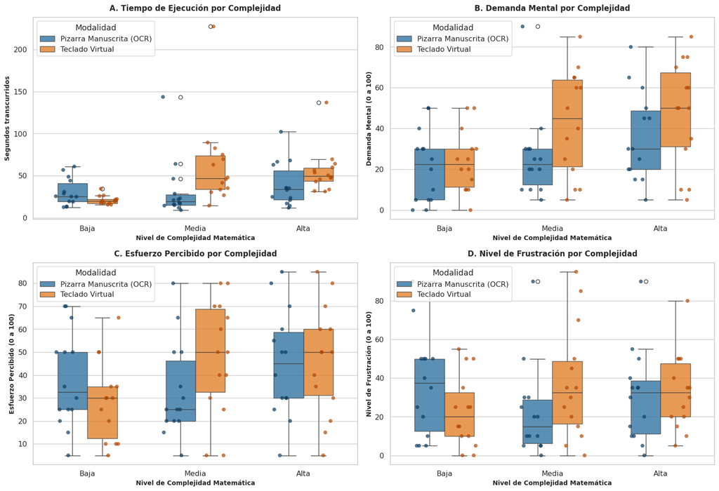

```python
# 5.1 Gráfico Combinado: Boxplots con Puntos Individuales (Stripplot) en Grilla 2x2
fig, axes = plt.subplots(2, 2, figsize=(16, 11))

vars_box = [
    ('seconds', 'A. Tiempo de Ejecución por Complejidad', 'Segundos transcurridos', axes[0, 0]),
    ('mentalDemand', 'B. Demanda Mental por Complejidad', 'Demanda Mental (0 a 100)', axes[0, 1]),
    ('effort', 'C. Esfuerzo Percibido por Complejidad', 'Esfuerzo Percibido (0 a 100)', axes[1, 0]),
    ('frustration', 'D. Nivel de Frustración por Complejidad', 'Nivel de Frustración (0 a 100)', axes[1, 1])
]

for col, title, ylab, ax in vars_box:
    sns.boxplot(data=df, x='complexity', y=col, hue='condicion_label',
                palette=PALETTE_LABELS, ax=ax, width=0.55, boxprops=dict(alpha=0.8), showcaps=True)
    sns.stripplot(data=df, x='complexity', y=col, hue='condicion_label',
                  palette={'Pizarra Manuscrita (OCR)': '#0b3c60', 'Teclado Virtual': '#b34700'},
                  dodge=True, jitter=0.2, alpha=0.7, size=6, ax=ax, legend=False)
    ax.set_title(title, fontsize=12, fontweight='bold', pad=10)
    ax.set_xlabel('Nivel de Complejidad Matemática', fontsize=10, fontweight='bold')
    ax.set_ylabel(ylab, fontsize=10, fontweight='bold')
    ax.legend(title='Modalidad', frameon=True, loc='upper left')

plt.tight_layout()
plt.show()
```

### 5.2 Trayectorias Individuales Intra-Sujeto: Slope Charts / Spaghetti Plots con Barra de Error (Gráfico 5.2)

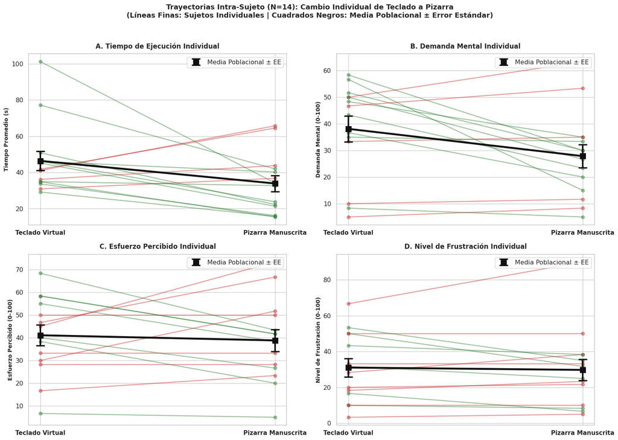

```python
# 5.2 Slope Charts / Spaghetti Plots con Barra de Error (Trayectorias Individuales Intra-Sujeto N=14 en Grilla 2x2)
fig, axes = plt.subplots(2, 2, figsize=(16, 11))

vars_plot = [
    ('seconds', 'Tiempo Promedio (s)', axes[0, 0], 'A. Tiempo de Ejecución Individual'),
    ('mentalDemand', 'Demanda Mental (0-100)', axes[0, 1], 'B. Demanda Mental Individual'),
    ('effort', 'Esfuerzo Percibido (0-100)', axes[1, 0], 'C. Esfuerzo Percibido Individual'),
    ('frustration', 'Nivel de Frustración (0-100)', axes[1, 1], 'D. Nivel de Frustración Individual')
]

for var, label, ax, title in vars_plot:
    piz_vals = user_summary[var]['pizarra']
    tec_vals = user_summary[var]['teclado']

    for u in user_summary.index:
        p_val = piz_vals[u]
        t_val = tec_vals[u]
        color = '#2e7d32' if p_val < t_val else '#c62828'
        ax.plot([0, 1], [t_val, p_val], marker='o', color=color, alpha=0.45, linewidth=1.8, markersize=6)

    means = [tec_vals.mean(), piz_vals.mean()]
    se_vals = [tec_vals.std(ddof=1) / np.sqrt(len(tec_vals)), piz_vals.std(ddof=1) / np.sqrt(len(piz_vals))]

    ax.plot([0, 1], means, color='#111111', linewidth=3.5, linestyle='-', zorder=10)
    ax.errorbar([0, 1], means, yerr=se_vals, fmt='s', color='#111111', ecolor='#111111',
                elinewidth=2.8, capsize=8, capthick=2.5, markersize=10,
                label='Media Poblacional ± EE', zorder=11)

    ax.set_xticks([0, 1])
    ax.set_xticklabels(['Teclado Virtual', 'Pizarra Manuscrita'], fontsize=11, fontweight='bold')
    ax.set_ylabel(label, fontsize=10, fontweight='bold')
    ax.set_title(title, fontsize=12, fontweight='bold', pad=10)
    ax.legend(frameon=True, loc='upper right')

plt.suptitle("Trayectorias Intra-Sujeto (N=14): Cambio Individual de Teclado a Pizarra\n(Líneas Finas: Sujetos Individuales | Cuadrados Negros: Media Poblacional ± Error Estándar)", fontsize=13, fontweight='bold', y=1.02)
plt.tight_layout()
plt.show()
```

### 5.3 Perfil Multidimensional NASA-TLX: Radar Chart (Gráfico 5.3)

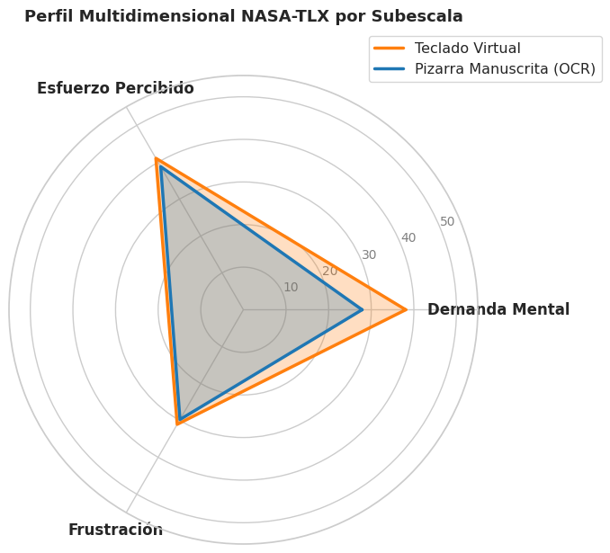

```python
# 5.3 Perfil Radial de Carga Cognitiva NASA-TLX (Subescalas Independientes)
categories = ['Demanda Mental', 'Esfuerzo Percibido', 'Frustración']
N_cat = len(categories)

means_pizarra = [df[df['condicion']=='pizarra']['mentalDemand'].mean(),
                 df[df['condicion']=='pizarra']['effort'].mean(),
                 df[df['condicion']=='pizarra']['frustration'].mean()]

means_teclado = [df[df['condicion']=='teclado']['mentalDemand'].mean(),
                 df[df['condicion']=='teclado']['effort'].mean(),
                 df[df['condicion']=='teclado']['frustration'].mean()]

angles = [n / float(N_cat) * 2 * np.pi for n in range(N_cat)]
angles += angles[:1]
means_pizarra += means_pizarra[:1]
means_teclado += means_teclado[:1]

fig, ax = plt.subplots(figsize=(7, 7), subplot_kw=dict(polar=True))

ax.plot(angles, means_teclado, linewidth=2.5, linestyle='solid', label='Teclado Virtual', color=COLOR_TECLADO)
ax.fill(angles, means_teclado, color=COLOR_TECLADO, alpha=0.25)

ax.plot(angles, means_pizarra, linewidth=2.5, linestyle='solid', label='Pizarra Manuscrita (OCR)', color=COLOR_PIZARRA)
ax.fill(angles, means_pizarra, color=COLOR_PIZARRA, alpha=0.25)

ax.set_xticks(angles[:-1])
ax.set_xticklabels(categories, fontsize=12, fontweight='bold')
ax.set_ylim(0, 55)
ax.set_yticks([10, 20, 30, 40, 50])
ax.set_yticklabels(['10', '20', '30', '40', '50'], color='gray', size=10)
plt.title('Perfil Multidimensional NASA-TLX por Subescala', size=13, fontweight='bold', y=1.1)
plt.legend(loc='upper right', bbox_to_anchor=(1.28, 1.1), frameon=True)
plt.show()
```

### 5.4 Efecto de Interacción Modalidad × Complejidad: Interaction Plots (Gráfico 5.4)

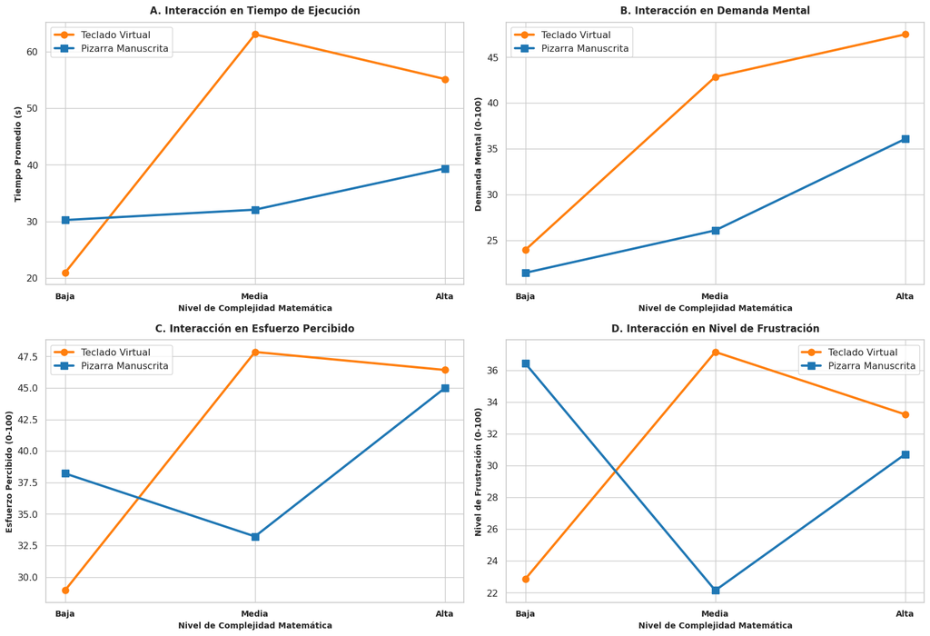

```python
# 5.4 Gráficos de Interacción: Modalidad × Complejidad (Grilla 2x2 para las 4 variables)
fig, axes = plt.subplots(2, 2, figsize=(16, 11))

complexity_labels = ['Baja', 'Media', 'Alta']
x_idx = np.arange(len(complexity_labels))

vars_inter = [
    ('seconds', 'A. Interacción en Tiempo de Ejecución', 'Tiempo Promedio (s)', axes[0, 0]),
    ('mentalDemand', 'B. Interacción en Demanda Mental', 'Demanda Mental (0-100)', axes[0, 1]),
    ('effort', 'C. Interacción en Esfuerzo Percibido', 'Esfuerzo Percibido (0-100)', axes[1, 0]),
    ('frustration', 'D. Interacción en Nivel de Frustración', 'Nivel de Frustración (0-100)', axes[1, 1])
]

for col, title, ylab, ax in vars_inter:
    inter_df = df.groupby(['complexity', 'condicion'])[col].mean().unstack('condicion')
    ax.plot(x_idx, inter_df['teclado'], marker='o', linewidth=2.8, markersize=8, label='Teclado Virtual', color=COLOR_TECLADO)
    ax.plot(x_idx, inter_df['pizarra'], marker='s', linewidth=2.8, markersize=8, label='Pizarra Manuscrita', color=COLOR_PIZARRA)
    ax.set_xticks(x_idx)
    ax.set_xticklabels(complexity_labels, fontsize=10, fontweight='bold')
    ax.set_ylabel(ylab, fontsize=10, fontweight='bold')
    ax.set_xlabel('Nivel de Complejidad Matemática', fontsize=10, fontweight='bold')
    ax.set_title(title, fontsize=12, fontweight='bold', pad=10)
    ax.legend(frameon=True)

plt.tight_layout()
plt.show()
```

### 5.5 Desglose por Ejercicio Individual ($E1$ a $E6$) (Gráfico 5.5)

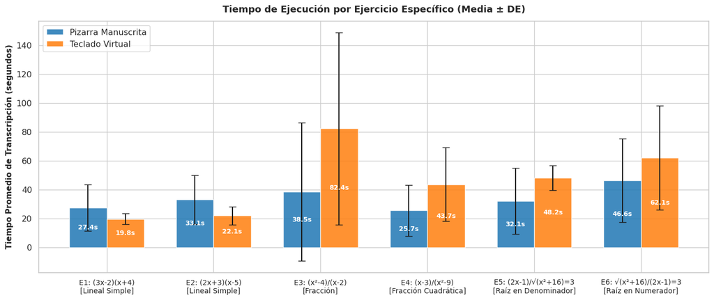

```python
# 5.5 Desglose Comparativo Ejercicio por Ejercicio (E1 a E6)
fig, ax = plt.subplots(figsize=(14, 6))

ex_time_mean = df.groupby(['exercise', 'condicion'])['seconds'].mean().unstack('condicion')
ex_time_std = df.groupby(['exercise', 'condicion'])['seconds'].std().unstack('condicion')

x = np.arange(len(ex_time_mean.index))
width = 0.35

rects1 = ax.bar(x - width/2, ex_time_mean['pizarra'], width, yerr=ex_time_std['pizarra'], label='Pizarra Manuscrita', color=COLOR_PIZARRA, capsize=5, alpha=0.85)
rects2 = ax.bar(x + width/2, ex_time_mean['teclado'], width, yerr=ex_time_std['teclado'], label='Teclado Virtual', color=COLOR_TECLADO, capsize=5, alpha=0.85)

ex_labels = [
    'E1: (3x-2)(x+4)\n[Lineal Simple]',
    'E2: (2x+3)(x-5)\n[Lineal Simple]',
    'E3: (x²-4)/(x-2)\n[Fracción]',
    'E4: (x-3)/(x²-9)\n[Fracción Cuadrática]',
    'E5: (2x-1)/√(x²+16)=3\n[Raíz en Denominador]',
    'E6: √(x²+16)/(2x-1)=3\n[Raíz en Numerador]'
]

ax.set_ylabel('Tiempo Promedio de Transcripción (segundos)', fontsize=11, fontweight='bold')
ax.set_title('Tiempo de Ejecución por Ejercicio Específico (Media ± DE)', fontsize=13, fontweight='bold', pad=12)
ax.set_xticks(x)
ax.set_xticklabels(ex_labels, fontsize=10)
ax.legend(frameon=True, loc='upper left')

for rect in rects1:
    h = rect.get_height()
    ax.annotate(f'{h:.1f}s', xy=(rect.get_x() + rect.get_width() / 2, h / 2),
                xytext=(0, 0), textcoords="offset points", ha='center', va='center', color='white', fontweight='bold', fontsize=9)
for rect in rects2:
    h = rect.get_height()
    ax.annotate(f'{h:.1f}s', xy=(rect.get_x() + rect.get_width() / 2, h / 2),
                xytext=(0, 0), textcoords="offset points", ha='center', va='center', color='white', fontweight='bold', fontsize=9)

plt.tight_layout()
plt.show()
```

### 5.6 Mapas de Calor de Correlación Inter-Variable (Gráfico 5.6)

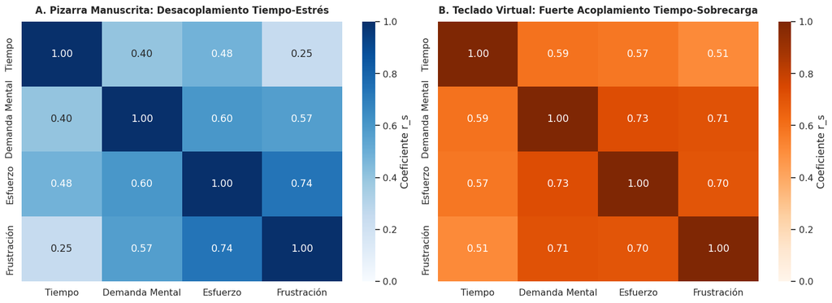

```python
# 5.6 Heatmaps de Correlación Inter-Variable (Pizarra vs. Teclado)
fig, axes = plt.subplots(1, 2, figsize=(15, 5.5))

lbls_heatmap = ['Tiempo', 'Demanda Mental', 'Esfuerzo', 'Frustración']

corr_piz = df[df['condicion']=='pizarra'][cols_corr].corr(method='spearman')
corr_tec = df[df['condicion']=='teclado'][cols_corr].corr(method='spearman')

sns.heatmap(corr_piz, annot=True, fmt=".2f", cmap='Blues', vmin=0, vmax=1,
            xticklabels=lbls_heatmap, yticklabels=lbls_heatmap, ax=axes[0], cbar_kws={'label': 'Coeficiente r_s'})
axes[0].set_title('A. Pizarra Manuscrita: Desacoplamiento Tiempo-Estrés', fontsize=12, fontweight='bold', pad=10)

sns.heatmap(corr_tec, annot=True, fmt=".2f", cmap='Oranges', vmin=0, vmax=1,
            xticklabels=lbls_heatmap, yticklabels=lbls_heatmap, ax=axes[1], cbar_kws={'label': 'Coeficiente r_s'})
axes[1].set_title('B. Teclado Virtual: Fuerte Acoplamiento Tiempo-Sobrecarga', fontsize=12, fontweight='bold', pad=10)

plt.tight_layout()
plt.show()
```

## 6. Evaluación Cualitativa Post-Estudio, Discusión Teórica y Conclusiones

### 6.1 Distribución de Preferencias Subjetivas (Post-Encuesta)

Tras completar las pruebas experimentales, los 14 estudiantes respondieron la encuesta de usabilidad (`Encuesta Final_ Evaluación del Sistema de Ecuaciones (Respuestas).xlsx`).

Tabla 6.1: Distribución Cuantitativa de Preferencias Subjetivas (Post-Encuesta, N=14)

| Dimensión de Usabilidad Evaluada | Pizarra Manuscrita (n) | Pizarra Manuscrita (%) | Teclado Virtual (n) | Teclado Virtual (%) |
| --- | --- | --- | --- | --- |
| Mayor Comodidad de Entrada de Ecuaciones | 8 | 57.1% | 6 | 42.9% |
| Preferencia para Seguir Usando en Mateo Tutor | 9 | 64.3% | 5 | 35.7% |
| Herramienta que Hizo más Fácil el Trabajo | 9 | 64.3% | 5 | 35.7% |
| Menor Distracción / Mejor Foco de Concentración | 7 | 50.0% | 7 | 50.0% |

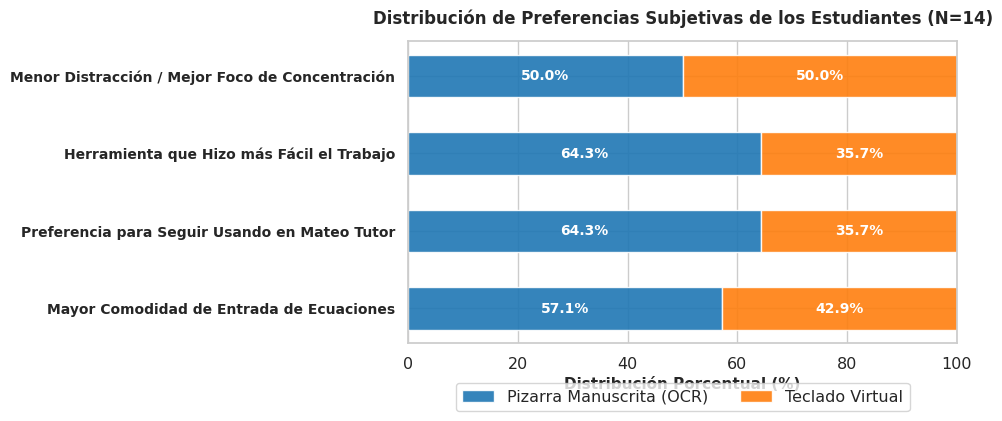

```python
# Carga de la Post-Encuesta
df_post = pd.read_excel('Encuesta Final_ Evaluación del Sistema de Ecuaciones (Respuestas).xlsx')
df_post.columns = [
    'Timestamp', 'Participante',
    'Comodidad', 'Comodidad_Justif',
    'Seguir_Usando', 'Seguir_Usando_Justif',
    'Facilidad_Trabajo', 'Facilidad_Trabajo_Justif',
    'Foco_Concentracion', 'Foco_Concentracion_Justif'
]

# Tabla 6.1: Distribución Cuantitativa de Preferencias
total_encuestados = len(df_post)

pref_comodidad_piz = df_post['Comodidad'].str.contains('MANUESCRITO|manuscrita|pizarra', case=False, na=False).sum()
pref_seguir_piz = df_post['Seguir_Usando'].str.contains('MANUESCRITO|manuscrita|pizarra', case=False, na=False).sum()
pref_facilidad_piz = df_post['Facilidad_Trabajo'].str.contains('MANUESCRITO|manuscrita|pizarra', case=False, na=False).sum()
pref_foco_piz = df_post['Foco_Concentracion'].str.contains('MANUESCRITO|manuscrita|pizarra', case=False, na=False).sum()

datos_preferencias = {
    'Dimensión de Usabilidad Evaluada': [
        'Mayor Comodidad de Entrada de Ecuaciones',
        'Preferencia para Seguir Usando en Mateo Tutor',
        'Herramienta que Hizo más Fácil el Trabajo',
        'Menor Distracción / Mejor Foco de Concentración'
    ],
    'Pizarra Manuscrita (n)': [
        pref_comodidad_piz,
        pref_seguir_piz,
        pref_facilidad_piz,
        pref_foco_piz
    ],
    'Pizarra Manuscrita (%)': [
        f"{(pref_comodidad_piz/total_encuestados)*100:.1f}%",
        f"{(pref_seguir_piz/total_encuestados)*100:.1f}%",
        f"{(pref_facilidad_piz/total_encuestados)*100:.1f}%",
        f"{(pref_foco_piz/total_encuestados)*100:.1f}%"
    ],
    'Teclado Virtual (n)': [
        total_encuestados - pref_comodidad_piz,
        total_encuestados - pref_seguir_piz,
        total_encuestados - pref_facilidad_piz,
        total_encuestados - pref_foco_piz
    ],
    'Teclado Virtual (%)': [
        f"{((total_encuestados - pref_comodidad_piz)/total_encuestados)*100:.1f}%",
        f"{((total_encuestados - pref_seguir_piz)/total_encuestados)*100:.1f}%",
        f"{((total_encuestados - pref_facilidad_piz)/total_encuestados)*100:.1f}%",
        f"{((total_encuestados - pref_foco_piz)/total_encuestados)*100:.1f}%"
    ]
}

df_tabla_61 = pd.DataFrame(datos_preferencias)
df_tabla_61.set_index('Dimensión de Usabilidad Evaluada', inplace=True)

styled_t61 = df_tabla_61.style.set_properties(subset=['Pizarra Manuscrita (n)', 'Pizarra Manuscrita (%)'], **{'background-color': '#ebf5fc', 'color': '#0b3c60', 'font-weight': 'bold', 'text-align': 'center'})
styled_t61 = styled_t61.set_properties(subset=['Teclado Virtual (n)', 'Teclado Virtual (%)'], **{'background-color': '#fff4eb', 'color': '#8a3800', 'font-weight': 'bold', 'text-align': 'center'})
styled_t61 = styled_t61.set_table_styles(CSS_TABLA_ACADEMICA)
styled_t61 = styled_t61.set_caption("Tabla 6.1: Distribución Cuantitativa de Preferencias Subjetivas (Post-Encuesta, N=14)")
display(styled_t61)

# Gráfico 6.1: Preferencias Subjetivas
fig, ax = plt.subplots(figsize=(10, 4.5))
y_pos = np.arange(len(df_tabla_61.index))
piz_pcts = [float(x.replace('%', '')) for x in df_tabla_61['Pizarra Manuscrita (%)']]
tec_pcts = [float(x.replace('%', '')) for x in df_tabla_61['Teclado Virtual (%)']]

ax.barh(y_pos, piz_pcts, color=COLOR_PIZARRA, label='Pizarra Manuscrita (OCR)', height=0.55, alpha=0.9)
ax.barh(y_pos, tec_pcts, left=piz_pcts, color=COLOR_TECLADO, label='Teclado Virtual', height=0.55, alpha=0.9)

ax.set_yticks(y_pos)
ax.set_yticklabels(df_tabla_61.index, fontsize=10, fontweight='bold')
ax.set_xlabel('Distribución Porcentual (%)', fontsize=11, fontweight='bold')
ax.set_title('Distribución de Preferencias Subjetivas de los Estudiantes (N=14)', fontsize=12, fontweight='bold', pad=12)
ax.set_xlim(0, 100)
ax.legend(loc='lower center', bbox_to_anchor=(0.5, -0.25), ncol=2, frameon=True)

for i in range(len(y_pos)):
    ax.text(piz_pcts[i] / 2, i, f"{piz_pcts[i]:.1f}%", ha='center', va='center', color='white', fontweight='bold', fontsize=10)
    ax.text(piz_pcts[i] + tec_pcts[i] / 2, i, f"{tec_pcts[i]:.1f}%", ha='center', va='center', color='white', fontweight='bold', fontsize=10)

plt.tight_layout()
plt.show()
```